# Mating Motivation EFA and Reliability Analysis

Graham Albert

December 1, 2017

#### To load the necessary packages into my R work space to conduct both EFA and CFA.

```r
require(psych)
```

###### for efa

```r
require(lavaan)
```

###### for cfa

```r
require(curl)
```

###### loading data

```r
require(mice)
```

###### missing data

```r
require(GPArotation)
```

##### for more advanced rotation.

```r
require(dplyr)
```

[output not shown]

#### for data manipulation.

```r
require(corrplot)
require(rlang)
require(yaml)
require(stringi)
require(semPlot)
```

#### for correlation plot depiction.

```r
require(gplots)
require(gridExtra)
require(moments)
```

### linearity depiction.

#### To load my data set for the mating motivation scale into the R work space.

```r
f <- curl("https://raw.githubusercontent.com/GrahamAlbert/Mating-Motivation-Project/master/MatingMotivationScaleEFA_20171201.csv")
MatingMotivationScaleV1<- read.csv(f, header = TRUE, sep = ",", stringsAsFactors = FALSE)
View(MatingMotivationScaleV1)
```

#### To determine variable names of the data set.

```r
MatingMotivationScaleV1<-MatingMotivationScaleV1[-1]
View(MatingMotivationScaleV1)
```

#### To obtain summary statistics for the data set.

```r
summary(MatingMotivationScaleV1)
```

```
##       MMS1            MMS2            MMS3           MMS4
##  Min.   :1.000   Min.   :1.000   Min.   :1.00   Min.   :1.000
##  1st Qu.:2.000   1st Qu.:1.000   1st Qu.:5.00   1st Qu.:2.000
##  Median :3.000   Median :2.000   Median :6.00   Median :4.000
##  Mean   :3.277   Mean   :2.852   Mean   :5.31   Mean   :3.819
##  3rd Qu.:5.000   3rd Qu.:4.000   3rd Qu.:6.00   3rd Qu.:5.000
##  Max.   :7.000   Max.   :7.000   Max.   :7.00   Max.   :7.000
##
##     MMS5_rc        MMS6_rc           MMS7            MMS8
##  Min.   :1.00   Min.   :1.000   Min.   :1.000   Min.   :1.000
##  1st Qu.:1.00   1st Qu.:2.000   1st Qu.:3.000   1st Qu.:1.000
##  Median :2.00   Median :3.000   Median :4.000   Median :2.000
##  Mean   :2.14   Mean   :3.328   Mean   :4.151   Mean   :2.554
##  3rd Qu.:3.00   3rd Qu.:4.000   3rd Qu.:5.000   3rd Qu.:4.000
##  Max.   :7.00   Max.   :7.000   Max.   :7.000   Max.   :7.000
##
##     MMS9_rc          MMS10           MMS11           MMS12
##  Min.   :1.000   Min.   :1.000   Min.   :1.000   Min.   :1.00
##  1st Qu.:3.000   1st Qu.:1.000   1st Qu.:4.000   1st Qu.:2.50
##  Median :4.000   Median :3.000   Median :6.000   Median :4.00
##  Mean   :4.133   Mean   :3.026   Mean   :5.277   Mean   :3.83
##  3rd Qu.:6.000   3rd Qu.:5.000   3rd Qu.:7.000   3rd Qu.:5.00
##  Max.   :7.000   Max.   :7.000   Max.   :7.000   Max.   :7.00
##
##      MMS13          MMS14_rc        MMS15_rc         MMS16
##  Min.   :1.000   Min.   :1.000   Min.   :1.000   Min.   :1.00
##  1st Qu.:5.000   1st Qu.:2.000   1st Qu.:2.000   1st Qu.:4.00
##  Median :6.000   Median :3.000   Median :3.000   Median :5.00
##  Mean   :5.672   Mean   :3.317   Mean   :3.151   Mean   :5.07
##  3rd Qu.:7.000   3rd Qu.:4.000   3rd Qu.:4.000   3rd Qu.:6.00
##  Max.   :7.000   Max.   :7.000   Max.   :7.000   Max.   :7.00
##
##      MMS17           MMS18           MMS19           MMS20
##  Min.   :1.000   Min.   :1.000   Min.   :1.000   Min.   :1.000
##  1st Qu.:2.000   1st Qu.:3.000   1st Qu.:4.000   1st Qu.:4.000
##  Median :4.000   Median :4.000   Median :5.000   Median :5.000
##  Mean   :3.594   Mean   :3.867   Mean   :4.613   Mean   :4.424
##  3rd Qu.:5.000   3rd Qu.:5.000   3rd Qu.:6.000   3rd Qu.:5.500
##  Max.   :7.000   Max.   :7.000   Max.   :7.000   Max.   :7.000
##
```

[output cut: 105 more lines]

```
##  Min.   :1.000   Min.   :1.000   Min.   :1.000   Min.   :1.000
##  1st Qu.:1.250   1st Qu.:1.000   1st Qu.:2.000   1st Qu.:1.000
##  Median :4.000   Median :3.000   Median :3.000   Median :2.000
##  Mean   :3.437   Mean   :2.919   Mean   :3.487   Mean   :2.845
##  3rd Qu.:5.000   3rd Qu.:4.000   3rd Qu.:5.000   3rd Qu.:4.000
##  Max.   :7.000   Max.   :7.000   Max.   :7.000   Max.   :7.000
##  NA's   :1       NA's   :1
##      MMS77           MMS78           MMS79
##  Min.   :1.000   Min.   :1.000   Min.   :1.000
##  1st Qu.:1.000   1st Qu.:2.500   1st Qu.:1.000
##  Median :2.000   Median :4.000   Median :2.000
##  Mean   :2.643   Mean   :3.993   Mean   :2.561
##  3rd Qu.:4.000   3rd Qu.:5.000   3rd Qu.:4.000
##  Max.   :7.000   Max.   :7.000   Max.   :7.000
##  NA's   :2
```

#### To screening for missing values.

#### To write a funtion to check for missng data.

```r
percentmiss=function(x){sum(is.na(x)/length(x))*100}
```

#### To check for missing data

```r
missing=apply(MatingMotivationScaleV1, 1,percentmiss)
table(missing)
```

```
## missing
##                0 1.26582278481013 2.53164556962025
##              251               17                3
```

#### To exclude participants who are mijssingn too much data.

```r
replacepeople=subset(MatingMotivationScaleV1, missing<=5)
```

#### Make sure taht the columns are not missing too much data.

```r
apply(replacepeople, 2, percentmiss)
```

```
##      MMS1      MMS2      MMS3      MMS4   MMS5_rc   MMS6_rc      MMS7
## 0.0000000 0.0000000 0.0000000 0.0000000 0.0000000 0.0000000 0.0000000
##      MMS8   MMS9_rc     MMS10     MMS11     MMS12     MMS13  MMS14_rc
## 0.0000000 0.0000000 0.0000000 0.0000000 0.0000000 0.0000000 0.0000000
##  MMS15_rc     MMS16     MMS17     MMS18     MMS19     MMS20     MMS21
## 0.0000000 0.0000000 0.0000000 0.0000000 0.0000000 0.0000000 0.0000000
##     MMS22     MMS23     MMS24  MMS25_rc     MMS26  MMS27_rc     MMS28
## 0.0000000 0.0000000 0.0000000 0.3690037 0.3690037 0.0000000 0.0000000
##     MMS29     MMS30     MMS31     MMS32     MMS33  MMS34_rc     MMS35
## 0.0000000 0.0000000 0.0000000 0.0000000 0.0000000 0.0000000 0.3690037
##     MMS36     MMS37     MMS38     MMS39  MMS40_rc     MMS41     MMS42
## 0.0000000 0.3690037 0.3690037 0.0000000 0.3690037 0.0000000 0.3690037
##     MMS43     MMS44     MMS45     MMS46     MMS47     MMS48     MMS49
## 0.0000000 0.0000000 0.0000000 0.0000000 0.0000000 0.0000000 0.0000000
##     MMS50     MMS51     MMS52     MMS53     MMS54     MMS55  MMS56_rc
## 0.0000000 0.0000000 0.0000000 0.0000000 0.0000000 0.7380074 0.3690037
##  MMS57_rc     MMS58     MMS59     MMS60     MMS61     MMS62     MMS63
## 0.0000000 0.0000000 0.3690037 0.0000000 0.0000000 0.0000000 0.0000000
##     MMS64     MMS65     MMS66     MMS67  MMS68_rc     MMS69  MMS70_rc
## 0.0000000 0.3690037 0.7380074 0.7380074 0.3690037 0.3690037 0.3690037
##     MMS71     MMS72     MMS73     MMS74  MMS75_rc     MMS76     MMS77
## 0.0000000 0.0000000 0.3690037 0.3690037 0.0000000 0.0000000 0.7380074
##     MMS78     MMS79
## 0.0000000 0.0000000
```

##### Base on an analysis of the columns it appears that the data is missing completely at random and we proceed with replacing the data using the package mice.

```r
tempnomiss = mice(replacepeople)
nomiss = complete (tempnomiss, 1)
summary(nomiss)
```

```
##       MMS1            MMS2            MMS3           MMS4
##  Min.   :1.000   Min.   :1.000   Min.   :1.00   Min.   :1.000
##  1st Qu.:2.000   1st Qu.:1.000   1st Qu.:5.00   1st Qu.:2.000
##  Median :3.000   Median :2.000   Median :6.00   Median :4.000
##  Mean   :3.277   Mean   :2.852   Mean   :5.31   Mean   :3.819
##  3rd Qu.:5.000   3rd Qu.:4.000   3rd Qu.:6.00   3rd Qu.:5.000
##  Max.   :7.000   Max.   :7.000   Max.   :7.00   Max.   :7.000
##     MMS5_rc        MMS6_rc           MMS7            MMS8
##  Min.   :1.00   Min.   :1.000   Min.   :1.000   Min.   :1.000
##  1st Qu.:1.00   1st Qu.:2.000   1st Qu.:3.000   1st Qu.:1.000
##  Median :2.00   Median :3.000   Median :4.000   Median :2.000
##  Mean   :2.14   Mean   :3.328   Mean   :4.151   Mean   :2.554
##  3rd Qu.:3.00   3rd Qu.:4.000   3rd Qu.:5.000   3rd Qu.:4.000
##  Max.   :7.00   Max.   :7.000   Max.   :7.000   Max.   :7.000
##     MMS9_rc          MMS10           MMS11           MMS12
##  Min.   :1.000   Min.   :1.000   Min.   :1.000   Min.   :1.00
##  1st Qu.:3.000   1st Qu.:1.000   1st Qu.:4.000   1st Qu.:2.50
##  Median :4.000   Median :3.000   Median :6.000   Median :4.00
##  Mean   :4.133   Mean   :3.026   Mean   :5.277   Mean   :3.83
##  3rd Qu.:6.000   3rd Qu.:5.000   3rd Qu.:7.000   3rd Qu.:5.00
##  Max.   :7.000   Max.   :7.000   Max.   :7.000   Max.   :7.00
##      MMS13          MMS14_rc        MMS15_rc         MMS16
##  Min.   :1.000   Min.   :1.000   Min.   :1.000   Min.   :1.00
##  1st Qu.:5.000   1st Qu.:2.000   1st Qu.:2.000   1st Qu.:4.00
##  Median :6.000   Median :3.000   Median :3.000   Median :5.00
##  Mean   :5.672   Mean   :3.317   Mean   :3.151   Mean   :5.07
##  3rd Qu.:7.000   3rd Qu.:4.000   3rd Qu.:4.000   3rd Qu.:6.00
##  Max.   :7.000   Max.   :7.000   Max.   :7.000   Max.   :7.00
##      MMS17           MMS18           MMS19           MMS20
##  Min.   :1.000   Min.   :1.000   Min.   :1.000   Min.   :1.000
##  1st Qu.:2.000   1st Qu.:3.000   1st Qu.:4.000   1st Qu.:4.000
##  Median :4.000   Median :4.000   Median :5.000   Median :5.000
##  Mean   :3.594   Mean   :3.867   Mean   :4.613   Mean   :4.424
##  3rd Qu.:5.000   3rd Qu.:5.000   3rd Qu.:6.000   3rd Qu.:5.500
##  Max.   :7.000   Max.   :7.000   Max.   :7.000   Max.   :7.000
##      MMS21           MMS22           MMS23           MMS24
##  Min.   :1.000   Min.   :1.000   Min.   :1.000   Min.   :1.000
##  1st Qu.:1.000   1st Qu.:4.000   1st Qu.:2.000   1st Qu.:1.000
##  Median :2.000   Median :5.000   Median :4.000   Median :2.000
##  Mean   :2.565   Mean   :4.613   Mean   :3.565   Mean   :2.852
```

[output cut: 85 more lines]

```
##  Max.   :7.000   Max.   :7.000   Max.   :7.000   Max.   :7.000
##      MMS73           MMS74          MMS75_rc         MMS76
##  Min.   :1.000   Min.   :1.000   Min.   :1.000   Min.   :1.000
##  1st Qu.:1.000   1st Qu.:1.000   1st Qu.:2.000   1st Qu.:1.000
##  Median :4.000   Median :3.000   Median :3.000   Median :2.000
##  Mean   :3.428   Mean   :2.934   Mean   :3.487   Mean   :2.845
##  3rd Qu.:5.000   3rd Qu.:4.000   3rd Qu.:5.000   3rd Qu.:4.000
##  Max.   :7.000   Max.   :7.000   Max.   :7.000   Max.   :7.000
##      MMS77           MMS78           MMS79
##  Min.   :1.000   Min.   :1.000   Min.   :1.000
##  1st Qu.:1.000   1st Qu.:2.500   1st Qu.:1.000
##  Median :2.000   Median :4.000   Median :2.000
##  Mean   :2.646   Mean   :3.993   Mean   :2.561
##  3rd Qu.:4.000   3rd Qu.:5.000   3rd Qu.:4.000
##  Max.   :7.000   Max.   :7.000   Max.   :7.000
```

#### To screen for multivariate outliers.

#### To screen for multivariate outliers in the data set nomiss we will use mahalanbis.

```r
cutoff = qchisq(0.99, ncol(nomiss))
mahal = mahalanobis(nomiss,
                    colMeans(nomiss),
                    cov(nomiss))
cutoff #####generates cutoff score
```

```
## [1] 111.144
```

```r
ncol(nomiss) #####determines df
```

```
## [1] 79
```

```r
summary(mahal<cutoff)
```

```
##    Mode   FALSE    TRUE
## logical      34     237
```

```r
noout = subset(nomiss, mahal<cutoff)
head(noout)
```

```
##   MMS1 MMS2 MMS3 MMS4 MMS5_rc MMS6_rc MMS7 MMS8 MMS9_rc MMS10 MMS11 MMS12
## 2    2    2    6    5       1       4    4    1       6     4     7     4
## 3    1    1    7    3       1       4    3    1       2     2     7     4
## 4    7    5    4    6       2       4    4    5       6     5     7     5
## 5    4    3    3    4       4       5    4    5       3     5     4     4
## 6    6    5    4    3       2       2    5    4       2     4     6     4
## 8    5    5    3    3       3       4    5    3       5     5     4     5
##   MMS13 MMS14_rc MMS15_rc MMS16 MMS17 MMS18 MMS19 MMS20 MMS21 MMS22 MMS23
## 2     6        3        4     5     4     4     4     4     1     5     4
## 3     7        1        3     5     2     3     5     3     1     5     1
## 4     5        4        3     3     6     4     4     3     6     6     5
## 5     4        4        4     5     3     4     4     3     4     5     5
## 6     4        2        3     4     3     3     4     6     3     3     2
## 8     5        4        3     5     4     3     4     3     4     5     3
##   MMS24 MMS25_rc MMS26 MMS27_rc MMS28 MMS29 MMS30 MMS31 MMS32 MMS33
```

[output cut: 41 more lines]

### Assumptions.

#### To screen for addivity.

```r
correl=cor(noout, use ="pairwise.complete.obs")
symnum(correl)
```

```
##          MMS1 MMS2 MMS3 MMS4 MMS5_ MMS6_ MMS7 MMS8 MMS9 MMS10 MMS11 MMS12
## MMS1     1
## MMS2     .    1
## MMS3               1
## MMS4     .              1
## MMS5_rc       .    .         1
## MMS6_rc            .               1
## MMS7                                     1
## MMS8     .    .    .         .           .    1
## MMS9_rc                                            1
## MMS10    .    .                          .    .         1
## MMS11              .         .                                1
## MMS12                                    .    .                     1
## MMS13              .         .                .               .
## MMS14_rc                                                      .
## MMS15_rc                                           .
## MMS16
## MMS17                                    .    .                     .
## MMS18                                                               .
## MMS19
## MMS20                                    .                          .
## MMS21    .    .    .         .                ,         .
## MMS22              .
## MMS23                                         .         .
## MMS24    .    .              .                .         .
## MMS25_rc
## MMS26              .                     .                          .
## MMS27_rc
## MMS28    .    .                               .         .     .
## MMS29    .    .                               .
## MMS30    .    .    .         .                .         .     .
## MMS31    .    .                               .         .
## MMS32    .    .                               .
## MMS33         .    .
## MMS34_rc
## MMS35    .    .    .         .                ,         .
## MMS36    .    .    .         .                .         .     .     .
## MMS37
## MMS38    .    .                               .         .
## MMS39    .    .              .                ,         .           .
```

[output cut: 587 more lines]

```
## MMS67
## MMS68_rc
## MMS69
## MMS70_rc
## MMS71
## MMS72
## MMS73
## MMS74
## MMS75_rc
## MMS76
## MMS77
## MMS78
## MMS79    1
## attr(,"legend")
## [1] 0 ' ' 0.3 '.' 0.6 ',' 0.8 '+' 0.9 '*' 0.95 'B' 1
```

#### To view new data set noout.

```r
View(noout)
```

### EFA assumption set up.

```r
random = rchisq(nrow(noout), 7)
fake = lm(random ~.,data=noout)
standardized = rstudent(fake)
fitted = scale(fake$fitted.values)
```

#### To test for normality.

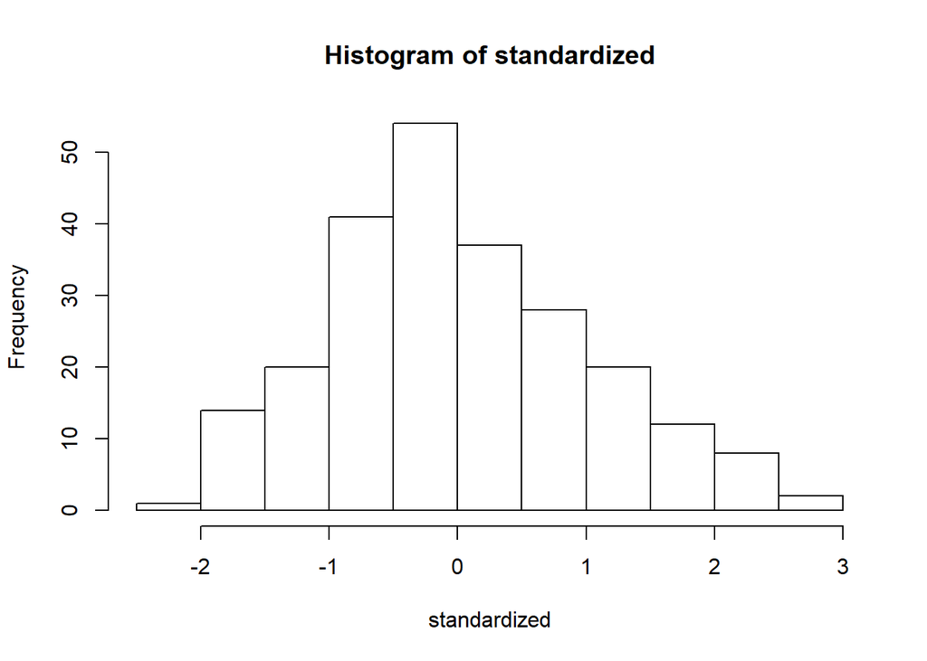

```r
hist(standardized)
```

####To test for linearity.

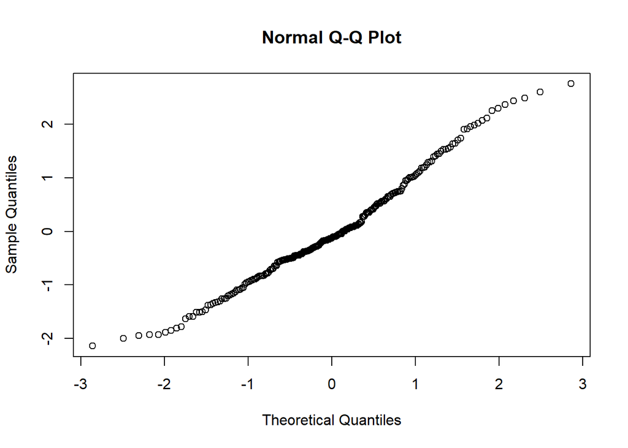

```r
qqnorm(standardized)
```

####Homogenity of Variance.

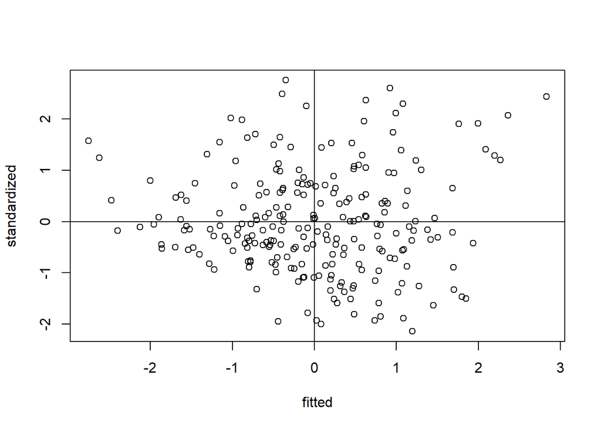

```r
plot(fitted, standardized)
abline(0,0)
abline(v=0)
```

###Runninng the efa analysis. ####correlation adequacy Bartlett’s test.

```r
cortest.bartlett(correl, n = nrow(noout))
```

```
## $chisq
## [1] 12027.48
##
## $p.value
## [1] 0
##
## $df
## [1] 3081
```

#### sampling adequacy KMO test.

```r
KMO(correl)
```

```
## Kaiser-Meyer-Olkin factor adequacy
## Call: KMO(r = correl)
## Overall MSA =  0.9
## MSA for each item =
##     MMS1     MMS2     MMS3     MMS4  MMS5_rc  MMS6_rc     MMS7     MMS8
##     0.88     0.92     0.90     0.70     0.84     0.65     0.80     0.94
##  MMS9_rc    MMS10    MMS11    MMS12    MMS13 MMS14_rc MMS15_rc    MMS16
##     0.59     0.87     0.82     0.86     0.89     0.72     0.61     0.66
##    MMS17    MMS18    MMS19    MMS20    MMS21    MMS22    MMS23    MMS24
##     0.93     0.87     0.84     0.78     0.95     0.84     0.92     0.92
## MMS25_rc    MMS26 MMS27_rc    MMS28    MMS29    MMS30    MMS31    MMS32
##     0.62     0.73     0.60     0.94     0.91     0.96     0.93     0.94
##    MMS33 MMS34_rc    MMS35    MMS36    MMS37    MMS38    MMS39 MMS40_rc
##     0.79     0.73     0.93     0.95     0.81     0.90     0.95     0.60
##    MMS41    MMS42    MMS43    MMS44    MMS45    MMS46    MMS47    MMS48
##     0.85     0.71     0.92     0.88     0.94     0.90     0.88     0.93
##    MMS49    MMS50    MMS51    MMS52    MMS53    MMS54    MMS55 MMS56_rc
##     0.95     0.94     0.70     0.89     0.81     0.96     0.96     0.80
## MMS57_rc    MMS58    MMS59    MMS60    MMS61    MMS62    MMS63    MMS64
##     0.81     0.95     0.88     0.82     0.91     0.95     0.93     0.95
##    MMS65    MMS66    MMS67 MMS68_rc    MMS69 MMS70_rc    MMS71    MMS72
##     0.90     0.93     0.90     0.76     0.86     0.77     0.89     0.75
##    MMS73    MMS74 MMS75_rc    MMS76    MMS77    MMS78    MMS79
##     0.92     0.95     0.55     0.95     0.95     0.78     0.95
```

#### detereminig number of factors for extraction.

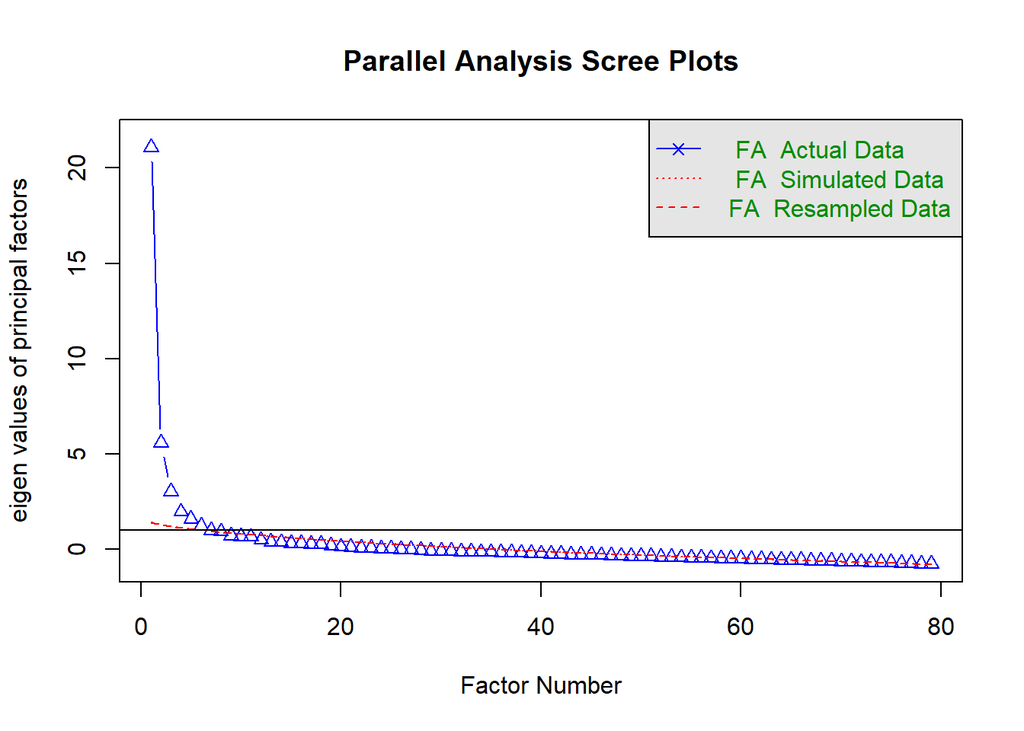

```
## Parallel analysis suggests that the number of factors =  8  and the number of components =  NA
```

```r
nofactors <- fa.parallel(noout,fm="ml",fa="fa")
```

```r
sum(nofactors$fa.values > 1.0)#####old kaiser criterion
```

```
## [1] 7
```

```r
sum(nofactors$fa.values > 0.7)#####new kaiser criterion
```

```
## [1] 9
```

#### I have elected to go withe fewest number of factors based on the old kaiser criterion and extract 7.

#### To conduct my first factor anlaysis with oblimin roation and fm being maximum likelihood.

```r
round1 = fa(noout,nfactors=7,rotate="oblimin", fm="ml")
round1
```

```
## Factor Analysis using method =  ml
## Call: fa(r = noout, nfactors = 7, rotate = "oblimin", fm = "ml")
## Standardized loadings (pattern matrix) based upon correlation matrix
##            ML1   ML7   ML4   ML2   ML3   ML5   ML6   h2   u2 com
## MMS1      0.09  0.35 -0.01 -0.07  0.10  0.06  0.38 0.44 0.56 2.4
## MMS2      0.15  0.56 -0.09 -0.13 -0.02 -0.03  0.17 0.46 0.54 1.6
## MMS3      0.05 -0.19 -0.13  0.55 -0.15 -0.22  0.06 0.56 0.44 2.0
## MMS4     -0.09  0.08 -0.15  0.20  0.11  0.09  0.55 0.36 0.64 1.7
## MMS5_rc  -0.02  0.37  0.05 -0.28  0.02  0.28  0.02 0.39 0.61 2.9
## MMS6_rc  -0.04  0.06  0.05 -0.33 -0.20  0.27  0.06 0.22 0.78 2.9
## MMS7      0.06  0.36  0.10  0.52  0.02  0.03 -0.23 0.42 0.58 2.3
## MMS8      0.06  0.55  0.12  0.06  0.23  0.12  0.05 0.65 0.35 1.6
## MMS9_rc   0.01 -0.48  0.27 -0.08 -0.04  0.27  0.10 0.29 0.71 2.4
## MMS10     0.02  0.61 -0.07  0.12  0.12 -0.03  0.00 0.44 0.56 1.2
## MMS11    -0.24 -0.09 -0.11  0.25  0.04 -0.33  0.14 0.36 0.64 3.7
## MMS12     0.03  0.10  0.29  0.46  0.15  0.15 -0.10 0.42 0.58 2.5
## MMS13    -0.21 -0.23 -0.09  0.51  0.00 -0.17  0.14 0.56 0.44 2.4
## MMS14_rc  0.14 -0.01  0.04 -0.10 -0.08  0.29 -0.08 0.13 0.87 2.1
## MMS15_rc -0.26 -0.16  0.42 -0.16 -0.02  0.28 -0.14 0.33 0.67 3.6
## MMS16    -0.22 -0.01  0.37  0.23 -0.03 -0.28  0.13 0.31 0.69 3.7
## MMS17     0.20  0.01  0.50  0.10  0.20 -0.03  0.00 0.54 0.46 1.8
## MMS18     0.08  0.11  0.47  0.35 -0.02  0.06  0.03 0.46 0.54 2.1
## MMS19     0.06 -0.20  0.44  0.14  0.01  0.01  0.31 0.38 0.62 2.6
## MMS20     0.02  0.17  0.14  0.56  0.02  0.16  0.01 0.40 0.60 1.5
## MMS21     0.16  0.52  0.15 -0.04  0.16  0.05  0.08 0.66 0.34 1.7
## MMS22     0.12 -0.06  0.13  0.51 -0.05  0.12  0.13 0.36 0.64 1.6
## MMS23     0.22  0.34  0.01  0.23  0.03  0.18  0.03 0.36 0.64 3.3
## MMS24     0.18  0.30  0.32 -0.06  0.15  0.10  0.12 0.59 0.41 3.7
## MMS25_rc  0.04 -0.14 -0.08  0.01 -0.12  0.25 -0.04 0.10 0.90 2.5
## MMS26    -0.08  0.04  0.05  0.55 -0.06 -0.09  0.20 0.41 0.59 1.4
## MMS27_rc  0.16 -0.06 -0.13  0.06 -0.21  0.47  0.23 0.29 0.71 2.4
## MMS28     0.34  0.24  0.34 -0.05  0.16 -0.02  0.04 0.67 0.33 3.3
## MMS29     0.33  0.21  0.11  0.10 -0.04  0.14  0.32 0.49 0.51 3.6
## MMS30     0.28  0.33  0.29 -0.12  0.06  0.08  0.09 0.61 0.39 3.7
## MMS31    -0.03  0.46  0.23 -0.16  0.17 -0.14  0.16 0.50 0.50 2.7
## MMS32     0.25  0.24  0.39 -0.02 -0.09 -0.07  0.23 0.50 0.50 3.4
## MMS33    -0.19 -0.31  0.34  0.26  0.06 -0.13  0.04 0.32 0.68 3.9
## MMS34_rc -0.06 -0.27 -0.02 -0.26  0.06  0.35  0.09 0.24 0.76 3.1
## MMS35     0.14  0.38  0.16 -0.17  0.31  0.03  0.06 0.65 0.35 3.2
## MMS36     0.26  0.27  0.21 -0.10  0.28  0.00  0.07 0.63 0.37 4.2
```

[output cut: 71 more lines]

```
## The total number of observations was  237  with Likelihood Chi Square =  3773.59  with prob <  4e-51
##
## Tucker Lewis Index of factoring reliability =  0.829
## RMSEA index =  0.055  and the 90 % confidence intervals are  0.042 NA
## BIC =  -10164.49
## Fit based upon off diagonal values = 0.98
## Measures of factor score adequacy
##                                                    ML1  ML7  ML4  ML2  ML3
## Correlation of (regression) scores with factors   0.96 0.94 0.94 0.93 0.96
## Multiple R square of scores with factors          0.92 0.89 0.88 0.87 0.92
## Minimum correlation of possible factor scores     0.85 0.78 0.77 0.74 0.84
##                                                    ML5  ML6
## Correlation of (regression) scores with factors   0.92 0.92
## Multiple R square of scores with factors          0.85 0.84
## Minimum correlation of possible factor scores     0.70 0.69
```

#### To conduct my second factor anlaysis with oblimin roation and fm being maximum likelihood.

```r
round2 = fa(noout[ ,-c(30,55,7,1,9,35,29,39,45,61,63,79,14,15,18,19,25,40,48,60,78)],nfactors=7,rotate="oblimin", fm="ml")
round2
```

```
## Factor Analysis using method =  ml
## Call: fa(r = noout[, -c(30, 55, 7, 1, 9, 35, 29, 39, 45, 61, 63, 79,
##     14, 15, 18, 19, 25, 40, 48, 60, 78)], nfactors = 7, rotate = "oblimin",
##     fm = "ml")
## Standardized loadings (pattern matrix) based upon correlation matrix
##            ML1   ML6   ML2   ML5   ML4   ML3   ML7   h2   u2 com
## MMS2      0.12  0.66 -0.12 -0.12 -0.09 -0.08  0.12 0.50 0.50 1.4
## MMS3      0.10 -0.16  0.56 -0.13 -0.27 -0.12  0.02 0.58 0.42 2.0
## MMS4     -0.05  0.01  0.21 -0.12  0.09  0.10  0.56 0.36 0.64 1.5
## MMS5_rc  -0.04  0.39 -0.26  0.00  0.29  0.00  0.01 0.40 0.60 2.7
## MMS6_rc  -0.09  0.10 -0.27  0.00  0.32 -0.21  0.06 0.22 0.78 3.3
## MMS8      0.01  0.68  0.08  0.11  0.09  0.14 -0.01 0.69 0.31 1.2
## MMS10    -0.01  0.67  0.09 -0.07 -0.05  0.06  0.00 0.43 0.57 1.1
## MMS11    -0.18 -0.14  0.26 -0.09 -0.35  0.07  0.10 0.37 0.63 3.3
## MMS12     0.02  0.16  0.47  0.28  0.18  0.12 -0.12 0.43 0.57 2.6
## MMS13    -0.21 -0.19  0.51 -0.08 -0.19 -0.02  0.13 0.55 0.45 2.2
## MMS16    -0.25  0.02  0.23  0.41 -0.26 -0.04  0.09 0.34 0.66 3.3
## MMS17     0.16 -0.02  0.04  0.56  0.04  0.19  0.01 0.56 0.44 1.4
## MMS20     0.04  0.20  0.54  0.11  0.16 -0.01  0.02 0.37 0.63 1.5
## MMS21     0.14  0.67  0.01  0.08  0.03  0.09 -0.01 0.72 0.28 1.2
## MMS22     0.14 -0.01  0.54  0.07  0.09 -0.05  0.11 0.36 0.64 1.3
## MMS23     0.17  0.36  0.24  0.05  0.19  0.02  0.03 0.36 0.64 3.0
## MMS24     0.18  0.27 -0.04  0.28  0.16  0.16  0.09 0.56 0.44 4.3
## MMS26    -0.09  0.16  0.57  0.02 -0.11 -0.10  0.18 0.43 0.57 1.6
## MMS27_rc  0.08 -0.01  0.11 -0.11  0.48 -0.23  0.25 0.27 0.73 2.4
## MMS28     0.30  0.24 -0.05  0.32  0.03  0.16  0.05 0.64 0.36 3.5
## MMS31    -0.05  0.51 -0.14  0.19 -0.13  0.14  0.10 0.49 0.51 1.9
## MMS32     0.21  0.13 -0.08  0.48 -0.02 -0.07  0.26 0.54 0.46 2.3
## MMS33    -0.17 -0.19  0.31  0.29 -0.14  0.02 -0.05 0.29 0.71 3.8
## MMS34_rc -0.05 -0.17 -0.17 -0.08  0.32  0.03  0.03 0.16 0.84 2.4
## MMS36     0.25  0.30 -0.09  0.18  0.02  0.26  0.06 0.62 0.38 3.9
## MMS37     0.04 -0.06  0.24  0.00 -0.07  0.01  0.48 0.35 0.65 1.6
## MMS38     0.04  0.04 -0.03 -0.02 -0.06  0.83 -0.02 0.73 0.27 1.0
## MMS41     0.11 -0.10  0.12  0.60 -0.07  0.02 -0.07 0.41 0.59 1.3
## MMS42     0.06 -0.03  0.60  0.08 -0.01  0.02 -0.10 0.39 0.61 1.1
## MMS43     0.05  0.56 -0.10  0.05 -0.05  0.20  0.09 0.60 0.40 1.4
## MMS44    -0.08  0.02 -0.01  0.02  0.03  0.89  0.11 0.82 0.18 1.0
## MMS46     0.03  0.06  0.05  0.80  0.02 -0.05 -0.02 0.68 0.32 1.0
## MMS47     0.06 -0.08  0.00  0.36 -0.01  0.04  0.41 0.37 0.63 2.1
## MMS49     0.40  0.08 -0.04  0.21  0.12  0.16  0.12 0.55 0.45 2.5
```

[output cut: 52 more lines]

```
## The total number of observations was  237  with Likelihood Chi Square =  1835.05  with prob <  1.5e-23
##
## Tucker Lewis Index of factoring reliability =  0.875
## RMSEA index =  0.051  and the 90 % confidence intervals are  0.039 NA
## BIC =  -5098.45
## Fit based upon off diagonal values = 0.98
## Measures of factor score adequacy
##                                                    ML1  ML6  ML2  ML5  ML4
## Correlation of (regression) scores with factors   0.95 0.95 0.92 0.93 0.91
## Multiple R square of scores with factors          0.91 0.89 0.85 0.86 0.83
## Minimum correlation of possible factor scores     0.81 0.79 0.70 0.72 0.65
##                                                    ML3  ML7
## Correlation of (regression) scores with factors   0.95 0.90
## Multiple R square of scores with factors          0.91 0.80
## Minimum correlation of possible factor scores     0.81 0.61
```

#### To conduct my third factor anlaysis with oblimin roation and fm being maximum likelihood.

```r
round3 = fa(noout[ ,-c(30,55,7,1,9,35,29,39,45,61,63,79,14,15,18,19,25,40,48,60,78,50,58,24)],nfactors=7,rotate="oblimin", fm="ml")
round3
```

```
## Factor Analysis using method =  ml
## Call: fa(r = noout[, -c(30, 55, 7, 1, 9, 35, 29, 39, 45, 61, 63, 79,
##     14, 15, 18, 19, 25, 40, 48, 60, 78, 50, 58, 24)], nfactors = 7,
##     rotate = "oblimin", fm = "ml")
## Standardized loadings (pattern matrix) based upon correlation matrix
##            ML1   ML6   ML2   ML5   ML4   ML3   ML7   h2   u2 com
## MMS2      0.12  0.65 -0.12 -0.09 -0.11 -0.08  0.12 0.49 0.51 1.4
## MMS3      0.09 -0.18  0.55 -0.28 -0.13 -0.12  0.02 0.58 0.42 2.0
## MMS4     -0.07 -0.01  0.18  0.10 -0.09  0.08  0.62 0.40 0.60 1.3
## MMS5_rc  -0.04  0.38 -0.27  0.30  0.01 -0.01  0.03 0.40 0.60 2.8
## MMS6_rc  -0.06  0.12 -0.26  0.30 -0.01 -0.22  0.02 0.21 0.79 3.3
## MMS8      0.01  0.68  0.08  0.10  0.11  0.13  0.00 0.69 0.31 1.2
## MMS10    -0.01  0.66  0.10 -0.05 -0.08  0.06 -0.01 0.42 0.58 1.1
## MMS11    -0.18 -0.13  0.27 -0.37 -0.10  0.06  0.09 0.38 0.62 3.1
## MMS12     0.04  0.19  0.50  0.17  0.24  0.12 -0.16 0.45 0.55 2.5
## MMS13    -0.20 -0.18  0.51 -0.20 -0.08 -0.02  0.13 0.55 0.45 2.2
## MMS16    -0.25  0.03  0.22 -0.26  0.41 -0.05  0.09 0.34 0.66 3.2
## MMS17     0.18 -0.01  0.04  0.05  0.55  0.20  0.00 0.55 0.45 1.5
## MMS20     0.02  0.18  0.52  0.16  0.13 -0.01  0.05 0.35 0.65 1.6
## MMS21     0.14  0.67  0.02  0.04  0.07  0.09 -0.01 0.72 0.28 1.2
## MMS22     0.14 -0.02  0.53  0.09  0.08 -0.06  0.13 0.36 0.64 1.4
## MMS23     0.17  0.36  0.24  0.19  0.04  0.03  0.03 0.35 0.65 2.9
## MMS26    -0.07  0.16  0.57 -0.12  0.02 -0.11  0.16 0.43 0.57 1.6
## MMS27_rc  0.09  0.01  0.12  0.46 -0.11 -0.24  0.22 0.26 0.74 2.4
## MMS28     0.31  0.25 -0.04  0.03  0.29  0.17  0.04 0.62 0.38 3.7
## MMS31    -0.02  0.52 -0.13 -0.13  0.17  0.13  0.07 0.49 0.51 1.7
## MMS32     0.20  0.14 -0.09 -0.02  0.48 -0.07  0.25 0.53 0.47 2.3
## MMS33    -0.16 -0.19  0.30 -0.14  0.30  0.02 -0.04 0.29 0.71 3.8
## MMS34_rc -0.03 -0.14 -0.15  0.30 -0.10  0.03 -0.01 0.15 0.85 2.3
## MMS36     0.26  0.33 -0.07  0.02  0.16  0.26  0.03 0.62 0.38 3.5
## MMS37     0.04 -0.07  0.23 -0.08  0.02  0.00  0.47 0.34 0.66 1.6
## MMS38     0.04  0.04 -0.03 -0.06 -0.01  0.83 -0.01 0.74 0.26 1.0
## MMS41     0.11 -0.11  0.10 -0.06  0.61  0.02 -0.05 0.42 0.58 1.2
## MMS42     0.06 -0.03  0.61 -0.01  0.07  0.03 -0.09 0.39 0.61 1.1
## MMS43     0.07  0.58 -0.08 -0.05  0.03  0.19  0.05 0.61 0.39 1.3
## MMS44    -0.07  0.04 -0.01  0.02  0.02  0.87  0.11 0.81 0.19 1.0
## MMS46     0.03  0.06  0.03  0.03  0.82 -0.05 -0.01 0.70 0.30 1.0
## MMS47     0.09 -0.06  0.01 -0.02  0.35  0.03  0.37 0.34 0.66 2.2
## MMS49     0.41  0.12 -0.02  0.11  0.18  0.16  0.08 0.54 0.46 2.2
## MMS51    -0.02 -0.09  0.58  0.02  0.08  0.04  0.04 0.37 0.63 1.1
```

[output cut: 49 more lines]

```
## The total number of observations was  237  with Likelihood Chi Square =  1583.54  with prob <  1.8e-18
##
## Tucker Lewis Index of factoring reliability =  0.884
## RMSEA index =  0.049  and the 90 % confidence intervals are  0.037 NA
## BIC =  -4546.16
## Fit based upon off diagonal values = 0.98
## Measures of factor score adequacy
##                                                    ML1  ML6  ML2  ML5  ML4
## Correlation of (regression) scores with factors   0.95 0.94 0.92 0.91 0.92
## Multiple R square of scores with factors          0.90 0.89 0.85 0.83 0.86
## Minimum correlation of possible factor scores     0.80 0.79 0.70 0.65 0.71
##                                                    ML3 ML7
## Correlation of (regression) scores with factors   0.95 0.9
## Multiple R square of scores with factors          0.90 0.8
## Minimum correlation of possible factor scores     0.80 0.6
```

#### To conduct my fourth factor anlaysis with oblimin roation and fm being maximum likelihood.

```r
round4 = fa(noout[ ,-c(30,55,7,1,9,35,29,39,45,61,63,79,14,15,18,19,25,40,48,60,78,50,58,24,28,33,34,47,53)],nfactors=7,rotate="oblimin", fm="ml")
round4
```

```
## Factor Analysis using method =  ml
## Call: fa(r = noout[, -c(30, 55, 7, 1, 9, 35, 29, 39, 45, 61, 63, 79,
##     14, 15, 18, 19, 25, 40, 48, 60, 78, 50, 58, 24, 28, 33, 34,
##     47, 53)], nfactors = 7, rotate = "oblimin", fm = "ml")
## Standardized loadings (pattern matrix) based upon correlation matrix
##            ML1   ML6   ML2   ML5   ML3   ML4   ML7   h2   u2 com
## MMS2      0.13  0.63 -0.12 -0.09 -0.07 -0.09  0.11 0.47 0.53 1.3
## MMS3      0.09 -0.19  0.53 -0.27 -0.12 -0.11  0.05 0.56 0.44 2.1
## MMS4     -0.11 -0.01  0.15  0.06  0.03 -0.05  0.71 0.50 0.50 1.2
## MMS5_rc  -0.06  0.37 -0.27  0.32 -0.01  0.02  0.07 0.41 0.59 3.0
## MMS6_rc  -0.04  0.16 -0.24  0.27 -0.22 -0.03 -0.05 0.20 0.80 3.7
## MMS8      0.01  0.67  0.07  0.12  0.13  0.11  0.02 0.69 0.31 1.2
## MMS10     0.00  0.65  0.10 -0.04  0.08 -0.09 -0.03 0.42 0.58 1.1
## MMS11    -0.15 -0.12  0.26 -0.41  0.05 -0.10  0.05 0.38 0.62 2.5
## MMS12     0.05  0.19  0.52  0.19  0.14  0.22 -0.18 0.47 0.53 2.5
## MMS13    -0.16 -0.18  0.51 -0.24 -0.03 -0.10  0.09 0.55 0.45 2.1
## MMS16    -0.22  0.03  0.23 -0.29 -0.06  0.40  0.05 0.32 0.68 3.3
## MMS17     0.15 -0.01  0.05  0.05  0.21  0.54  0.00 0.54 0.46 1.5
## MMS20     0.00  0.14  0.52  0.17 -0.01  0.16  0.09 0.36 0.64 1.7
## MMS21     0.13  0.66  0.00  0.07  0.09  0.08  0.03 0.71 0.29 1.2
## MMS22     0.14 -0.03  0.52  0.09 -0.07  0.07  0.16 0.36 0.64 1.5
## MMS23     0.15  0.34  0.24  0.20  0.04  0.04  0.05 0.35 0.65 3.1
## MMS26    -0.03  0.18  0.58 -0.17 -0.12 -0.01  0.09 0.43 0.57 1.5
## MMS27_rc  0.12  0.05  0.12  0.39 -0.25 -0.11  0.17 0.21 0.79 2.9
## MMS31    -0.02  0.51 -0.13 -0.14  0.14  0.19  0.05 0.50 0.50 1.8
## MMS32     0.18  0.14 -0.08 -0.05 -0.07  0.51  0.23 0.53 0.47 2.0
## MMS36     0.25  0.33 -0.06  0.02  0.27  0.16  0.02 0.62 0.38 3.5
## MMS37     0.07 -0.04  0.24 -0.16  0.00  0.01  0.38 0.29 0.71 2.2
## MMS38     0.02  0.03 -0.03 -0.05  0.85 -0.01  0.00 0.75 0.25 1.0
## MMS41     0.09 -0.12  0.11 -0.06  0.02  0.63 -0.04 0.43 0.57 1.2
## MMS42     0.03 -0.08  0.61  0.01  0.04  0.11 -0.04 0.40 0.60 1.1
## MMS43     0.08  0.59 -0.08 -0.05  0.19  0.03  0.03 0.62 0.38 1.3
## MMS44    -0.07  0.06  0.00 -0.01  0.86  0.01  0.08 0.80 0.20 1.0
## MMS46     0.00  0.04  0.04  0.02 -0.06  0.84 -0.02 0.71 0.29 1.0
## MMS49     0.39  0.13 -0.01  0.11  0.17  0.20  0.07 0.54 0.46 2.5
## MMS51    -0.03 -0.11  0.58  0.01  0.04  0.11  0.07 0.39 0.61 1.2
## MMS52    -0.01  0.19 -0.12 -0.21  0.06  0.12  0.59 0.56 0.44 1.7
## MMS54     0.35  0.12  0.01  0.22  0.26  0.18  0.07 0.59 0.41 3.6
## MMS56_rc  0.02  0.10 -0.09  0.56 -0.05  0.06 -0.09 0.40 0.60 1.2
## MMS57_rc -0.08  0.02 -0.03  0.65  0.09 -0.01  0.01 0.45 0.55 1.1
```

[output cut: 44 more lines]

```
## The total number of observations was  237  with Likelihood Chi Square =  1215.14  with prob <  4.9e-12
##
## Tucker Lewis Index of factoring reliability =  0.909
## RMSEA index =  0.046  and the 90 % confidence intervals are  0.033 NA
## BIC =  -3684.24
## Fit based upon off diagonal values = 0.98
## Measures of factor score adequacy
##                                                    ML1  ML6  ML2  ML5  ML3
## Correlation of (regression) scores with factors   0.94 0.94 0.92 0.91 0.95
## Multiple R square of scores with factors          0.89 0.89 0.84 0.83 0.90
## Minimum correlation of possible factor scores     0.78 0.78 0.69 0.66 0.80
##                                                    ML4  ML7
## Correlation of (regression) scores with factors   0.92 0.89
## Multiple R square of scores with factors          0.85 0.80
## Minimum correlation of possible factor scores     0.71 0.59
```

#### To conduct my fifth factor anlaysis with oblimin roation and fm being maximum likelihood.

```r
round5 = fa(noout[ ,-c(30,55,7,1,9,35,29,39,45,61,63,79,14,15,18,19,25,40,48,60,78,50,58,24,28,33,34,47,53,5,6)],nfactors=7,rotate="oblimin", fm="ml")
round5
```

```
## Factor Analysis using method =  ml
## Call: fa(r = noout[, -c(30, 55, 7, 1, 9, 35, 29, 39, 45, 61, 63, 79,
##     14, 15, 18, 19, 25, 40, 48, 60, 78, 50, 58, 24, 28, 33, 34,
##     47, 53, 5, 6)], nfactors = 7, rotate = "oblimin", fm = "ml")
## Standardized loadings (pattern matrix) based upon correlation matrix
##            ML1   ML6   ML2   ML5   ML3   ML4   ML7   h2   u2 com
## MMS2      0.12  0.63 -0.13 -0.08 -0.08 -0.09  0.10 0.47 0.53 1.3
## MMS3      0.09 -0.19  0.52 -0.26 -0.13 -0.11  0.05 0.54 0.46 2.1
## MMS4     -0.12  0.01  0.15  0.07  0.02 -0.05  0.72 0.51 0.49 1.2
## MMS8     -0.02  0.72  0.06  0.12  0.09  0.10  0.02 0.71 0.29 1.2
## MMS10    -0.02  0.67  0.09 -0.04  0.06 -0.09 -0.03 0.42 0.58 1.1
## MMS11    -0.15 -0.11  0.26 -0.39  0.04 -0.10  0.06 0.37 0.63 2.6
## MMS12     0.05  0.19  0.52  0.18  0.14  0.21 -0.19 0.47 0.53 2.5
## MMS13    -0.15 -0.18  0.51 -0.24 -0.03 -0.10  0.09 0.54 0.46 2.1
## MMS16    -0.22  0.02  0.23 -0.30 -0.05  0.39  0.05 0.32 0.68 3.3
## MMS17     0.14  0.00  0.05  0.06  0.21  0.54  0.00 0.54 0.46 1.5
## MMS20     0.00  0.14  0.52  0.16  0.00  0.15  0.09 0.36 0.64 1.6
## MMS21     0.10  0.69 -0.01  0.07  0.07  0.07  0.03 0.72 0.28 1.1
## MMS22     0.14 -0.02  0.52  0.09 -0.06  0.07  0.16 0.36 0.64 1.5
## MMS23     0.15  0.34  0.23  0.20  0.05  0.04  0.04 0.34 0.66 3.1
## MMS26    -0.01  0.17  0.59 -0.18 -0.11 -0.02  0.08 0.44 0.56 1.5
## MMS27_rc  0.12  0.04  0.11  0.38 -0.24 -0.12  0.16 0.20 0.80 2.9
## MMS31    -0.02  0.50 -0.13 -0.15  0.14  0.18  0.05 0.49 0.51 1.8
## MMS32     0.19  0.13 -0.08 -0.05 -0.06  0.51  0.22 0.53 0.47 2.0
## MMS36     0.24  0.33 -0.06  0.02  0.28  0.16  0.02 0.62 0.38 3.5
## MMS37     0.09 -0.06  0.24 -0.17  0.02  0.01  0.37 0.30 0.70 2.4
## MMS38     0.02  0.01 -0.02 -0.06  0.86 -0.01 -0.01 0.75 0.25 1.0
## MMS41     0.08 -0.11  0.11 -0.06  0.01  0.63 -0.04 0.42 0.58 1.2
## MMS42     0.05 -0.09  0.61  0.00  0.05  0.10 -0.05 0.41 0.59 1.1
## MMS43     0.08  0.59 -0.09 -0.05  0.19  0.03  0.03 0.62 0.38 1.3
## MMS44    -0.08  0.05  0.01 -0.01  0.87  0.01  0.08 0.80 0.20 1.0
## MMS46    -0.01  0.05  0.04  0.02 -0.06  0.84 -0.02 0.72 0.28 1.0
## MMS49     0.38  0.13 -0.01  0.11  0.18  0.20  0.07 0.54 0.46 2.6
## MMS51    -0.02 -0.12  0.59  0.00  0.05  0.10  0.06 0.40 0.60 1.2
## MMS52    -0.02  0.20 -0.13 -0.20  0.06  0.12  0.59 0.56 0.44 1.7
## MMS54     0.33  0.13  0.00  0.22  0.25  0.18  0.07 0.59 0.41 3.9
## MMS56_rc  0.00  0.13 -0.11  0.57 -0.07  0.06 -0.08 0.41 0.59 1.3
## MMS57_rc -0.09  0.04 -0.04  0.65  0.08 -0.01  0.02 0.46 0.54 1.1
## MMS59     0.67  0.11  0.09 -0.24 -0.18 -0.02  0.05 0.53 0.47 1.5
## MMS62     0.39  0.09 -0.06  0.13  0.22  0.13  0.11 0.53 0.47 2.6
```

[output cut: 42 more lines]

```
## The total number of observations was  237  with Likelihood Chi Square =  1102.06  with prob <  4.7e-11
##
## Tucker Lewis Index of factoring reliability =  0.914
## RMSEA index =  0.046  and the 90 % confidence intervals are  0.033 NA
## BIC =  -3343.48
## Fit based upon off diagonal values = 0.98
## Measures of factor score adequacy
##                                                    ML1  ML6  ML2  ML5  ML3
## Correlation of (regression) scores with factors   0.94 0.94 0.92 0.91 0.95
## Multiple R square of scores with factors          0.89 0.89 0.84 0.82 0.90
## Minimum correlation of possible factor scores     0.77 0.78 0.68 0.65 0.81
##                                                    ML4  ML7
## Correlation of (regression) scores with factors   0.92 0.89
## Multiple R square of scores with factors          0.85 0.80
## Minimum correlation of possible factor scores     0.71 0.59
```

#### To conduct my sixth factor anlaysis with oblimin roation and fm being maximum likelihood.

```r
finalmodel= fa(noout[ ,-c(30,55,7,1,9,35,29,39,45,61,63,79,14,15,18,19,25,40,48,60,78,50,58,24,28,33,34,47,53,5,6,16,67)],nfactors=7,rotate="oblimin", fm="ml")
finalmodel
```

```
## Factor Analysis using method =  ml
## Call: fa(r = noout[, -c(30, 55, 7, 1, 9, 35, 29, 39, 45, 61, 63, 79,
##     14, 15, 18, 19, 25, 40, 48, 60, 78, 50, 58, 24, 28, 33, 34,
##     47, 53, 5, 6, 16, 67)], nfactors = 7, rotate = "oblimin",
##     fm = "ml")
## Standardized loadings (pattern matrix) based upon correlation matrix
##            ML1   ML6   ML2   ML3   ML5   ML4   ML7   h2   u2 com
## MMS2      0.12  0.63 -0.13 -0.08 -0.09 -0.07  0.09 0.45 0.55 1.3
## MMS3      0.10 -0.18  0.52 -0.13 -0.26 -0.11  0.06 0.54 0.46 2.1
## MMS4     -0.13  0.03  0.14  0.00  0.03 -0.03  0.76 0.57 0.43 1.1
## MMS8     -0.02  0.72  0.06  0.09  0.12  0.10  0.03 0.71 0.29 1.1
## MMS10    -0.02  0.67  0.09  0.06 -0.04 -0.08 -0.02 0.42 0.58 1.1
## MMS11    -0.14 -0.10  0.26  0.03 -0.41 -0.11  0.07 0.37 0.63 2.4
## MMS12     0.03  0.18  0.53  0.14  0.18  0.22 -0.18 0.48 0.52 2.4
## MMS13    -0.12 -0.18  0.51 -0.03 -0.24 -0.12  0.08 0.52 0.48 2.1
## MMS17     0.14 -0.01  0.06  0.21  0.06  0.54 -0.01 0.53 0.47 1.5
## MMS20    -0.01  0.13  0.52  0.00  0.15  0.17  0.09 0.37 0.63 1.6
## MMS21     0.10  0.70 -0.01  0.06  0.07  0.08  0.04 0.72 0.28 1.1
## MMS22     0.13 -0.01  0.51 -0.07  0.07  0.07  0.17 0.36 0.64 1.5
## MMS23     0.15  0.33  0.23  0.05  0.19  0.04  0.04 0.34 0.66 3.1
## MMS26    -0.01  0.17  0.59 -0.11 -0.18 -0.02  0.07 0.43 0.57 1.5
## MMS27_rc  0.14  0.03  0.11 -0.23  0.39 -0.13  0.14 0.20 0.80 2.8
## MMS31    -0.01  0.50 -0.12  0.14 -0.15  0.18  0.03 0.49 0.51 1.8
## MMS32     0.17  0.13 -0.07 -0.07 -0.07  0.53  0.20 0.53 0.47 1.8
## MMS36     0.25  0.32 -0.06  0.28  0.03  0.15  0.00 0.62 0.38 3.5
## MMS37     0.10 -0.06  0.24  0.03 -0.18  0.02  0.32 0.27 0.73 2.9
## MMS38     0.02  0.01 -0.02  0.87 -0.05 -0.02 -0.01 0.76 0.24 1.0
## MMS41     0.08 -0.11  0.12  0.01 -0.06  0.62 -0.03 0.40 0.60 1.2
## MMS42     0.03 -0.10  0.62  0.05 -0.01  0.11 -0.03 0.42 0.58 1.1
## MMS43     0.09  0.60 -0.09  0.18 -0.06  0.01  0.03 0.62 0.38 1.3
## MMS44    -0.07  0.06  0.01  0.86 -0.02  0.00  0.07 0.79 0.21 1.0
## MMS46    -0.03  0.05  0.06 -0.07 -0.01  0.87 -0.02 0.73 0.27 1.0
## MMS49     0.39  0.12 -0.01  0.18  0.12  0.20  0.06 0.54 0.46 2.6
## MMS51    -0.03 -0.13  0.59  0.05 -0.01  0.10  0.07 0.40 0.60 1.2
## MMS52     0.01  0.21 -0.12  0.06 -0.24  0.12  0.55 0.54 0.46 2.0
## MMS54     0.33  0.13  0.00  0.25  0.23  0.17  0.07 0.59 0.41 3.8
## MMS56_rc  0.00  0.12 -0.11 -0.07  0.59  0.04 -0.06 0.42 0.58 1.2
## MMS57_rc -0.10  0.02 -0.05  0.09  0.65 -0.01  0.02 0.45 0.55 1.1
## MMS59     0.68  0.11  0.09 -0.18 -0.23 -0.02  0.03 0.54 0.46 1.5
## MMS62     0.38  0.09 -0.07  0.22  0.13  0.15  0.11 0.53 0.47 2.7
```

[output cut: 41 more lines]

```
## The total number of observations was  237  with Likelihood Chi Square =  978.82  with prob <  3.1e-09
##
## Tucker Lewis Index of factoring reliability =  0.923
## RMSEA index =  0.044  and the 90 % confidence intervals are  0.031 NA
## BIC =  -3034.74
## Fit based upon off diagonal values = 0.99
## Measures of factor score adequacy
##                                                    ML1  ML6  ML2  ML3  ML5
## Correlation of (regression) scores with factors   0.94 0.94 0.91 0.95 0.91
## Multiple R square of scores with factors          0.89 0.89 0.84 0.90 0.82
## Minimum correlation of possible factor scores     0.77 0.79 0.67 0.81 0.64
##                                                    ML4  ML7
## Correlation of (regression) scores with factors   0.92 0.89
## Multiple R square of scores with factors          0.86 0.79
## Minimum correlation of possible factor scores     0.71 0.58
```

#### To compute the CFI.

```r
CFI<-1-((finalmodel$STATISTIC-finalmodel$dof)/(finalmodel$null.chisq-finalmodel$null.dof))
CFI
```

```
## [1] 0.9470524
```

#### Reliablity.

```r
factor1=c(49,54,59,62,64,66,69,73,74,76,77)
factor2=c(3,12,13,20,22,26,42,51)
factor3=c(38,44,65)
factor4=c(17,32,41,46)
factor5=c(11,27,56,57,68,70,75)
factor6=c(2,8,10,21,23,31,36,43)
factor7=c(4,37,52,71,72)
```

##### Alpla reliability.

```r
alpha(noout[,factor1])
```

```
##
## Reliability analysis
## Call: alpha(x = noout[, factor1])
##
##   raw_alpha std.alpha G6(smc) average_r S/N    ase mean  sd
##       0.91      0.91    0.92      0.49  11 0.0084  3.1 1.3
##
##  lower alpha upper     95% confidence boundaries
## 0.9 0.91 0.93
##
##  Reliability if an item is dropped:
##       raw_alpha std.alpha G6(smc) average_r  S/N alpha se
## MMS49      0.90      0.91    0.91      0.49  9.6   0.0093
## MMS54      0.91      0.91    0.91      0.49  9.7   0.0093
## MMS59      0.91      0.91    0.91      0.52 10.7   0.0084
## MMS62      0.91      0.91    0.91      0.49  9.7   0.0092
## MMS64      0.90      0.91    0.91      0.49  9.6   0.0093
## MMS66      0.90      0.91    0.91      0.49  9.6   0.0093
## MMS69      0.91      0.91    0.92      0.51 10.5   0.0086
## MMS73      0.91      0.91    0.91      0.50  9.8   0.0091
## MMS74      0.90      0.90    0.91      0.48  9.4   0.0095
## MMS76      0.90      0.90    0.91      0.48  9.3   0.0096
## MMS77      0.90      0.90    0.91      0.48  9.2   0.0096
##
##  Item statistics
##         n raw.r std.r r.cor r.drop mean  sd
## MMS49 237  0.76  0.75  0.72   0.69  3.0 1.9
## MMS54 237  0.74  0.74  0.71   0.68  2.9 1.8
## MMS59 237  0.61  0.60  0.56   0.51  4.1 1.8
## MMS62 237  0.74  0.74  0.72   0.68  2.9 1.8
## MMS64 237  0.75  0.75  0.72   0.68  2.9 1.7
## MMS66 237  0.75  0.76  0.73   0.69  2.8 1.6
## MMS69 237  0.62  0.63  0.57   0.54  3.9 1.7
## MMS73 237  0.73  0.72  0.69   0.65  3.5 1.9
## MMS74 237  0.78  0.78  0.76   0.73  3.0 1.7
## MMS76 237  0.80  0.80  0.78   0.75  2.9 1.8
## MMS77 237  0.81  0.81  0.80   0.76  2.7 1.6
##
## Non missing response frequency for each item
##          1    2    3    4    5    6    7 miss
## MMS49 0.31 0.18 0.09 0.16 0.13 0.11 0.02    0
## MMS54 0.31 0.21 0.10 0.12 0.16 0.08 0.02    0
## MMS59 0.13 0.14 0.08 0.17 0.25 0.16 0.07    0
## MMS62 0.31 0.19 0.14 0.14 0.13 0.06 0.03    0
## MMS64 0.29 0.20 0.15 0.11 0.17 0.06 0.02    0
## MMS66 0.27 0.29 0.09 0.16 0.13 0.06 0.00    0
## MMS69 0.14 0.10 0.11 0.16 0.31 0.13 0.03    0
## MMS73 0.24 0.13 0.12 0.14 0.22 0.11 0.04    0
## MMS74 0.26 0.22 0.16 0.15 0.15 0.05 0.02    0
## MMS76 0.30 0.22 0.13 0.12 0.14 0.07 0.02    0
## MMS77 0.32 0.24 0.12 0.17 0.08 0.06 0.01    0
```

```r
alpha(noout[,factor2])
```

```
##
## Reliability analysis
## Call: alpha(x = noout[, factor2])
##
##   raw_alpha std.alpha G6(smc) average_r S/N   ase mean   sd
##       0.78      0.78    0.79      0.31 3.6 0.021  4.9 0.87
##
##  lower alpha upper     95% confidence boundaries
## 0.74 0.78 0.82
##
##  Reliability if an item is dropped:
##       raw_alpha std.alpha G6(smc) average_r S/N alpha se
## MMS3       0.76      0.76    0.76      0.31 3.2    0.024
## MMS12      0.78      0.78    0.78      0.34 3.5    0.022
## MMS13      0.77      0.77    0.77      0.32 3.4    0.023
## MMS20      0.76      0.77    0.77      0.32 3.3    0.024
## MMS22      0.76      0.76    0.77      0.31 3.2    0.024
## MMS26      0.75      0.75    0.76      0.30 3.0    0.025
## MMS42      0.74      0.74    0.75      0.29 2.9    0.026
## MMS51      0.75      0.75    0.75      0.30 3.0    0.025
##
##  Item statistics
##         n raw.r std.r r.cor r.drop mean  sd
## MMS3  237  0.60  0.62  0.56   0.47  5.4 1.3
## MMS12 237  0.56  0.53  0.44   0.38  3.8 1.5
## MMS13 237  0.55  0.58  0.51   0.42  5.7 1.2
## MMS20 237  0.61  0.60  0.52   0.46  4.5 1.4
## MMS22 237  0.65  0.63  0.55   0.49  4.7 1.5
## MMS26 237  0.68  0.68  0.62   0.55  4.9 1.4
## MMS42 237  0.71  0.71  0.67   0.59  4.9 1.4
## MMS51 237  0.68  0.69  0.63   0.55  5.1 1.4
##
## Non missing response frequency for each item
##          1    2    3    4    5    6    7 miss
## MMS3  0.02 0.02 0.05 0.14 0.24 0.36 0.18    0
## MMS12 0.07 0.16 0.17 0.23 0.22 0.13 0.03    0
## MMS13 0.01 0.01 0.04 0.08 0.22 0.38 0.27    0
## MMS20 0.03 0.05 0.11 0.27 0.29 0.20 0.05    0
## MMS22 0.05 0.06 0.08 0.23 0.26 0.23 0.09    0
## MMS26 0.03 0.05 0.08 0.16 0.33 0.25 0.10    0
## MMS42 0.02 0.04 0.06 0.26 0.22 0.30 0.10    0
## MMS51 0.01 0.04 0.05 0.19 0.25 0.31 0.14    0
```

```r
alpha(noout[,factor3])
```

```
##
## Reliability analysis
## Call: alpha(x = noout[, factor3])
##
##   raw_alpha std.alpha G6(smc) average_r S/N   ase mean  sd
##       0.86      0.86    0.82      0.68 6.3 0.015    3 1.5
##
##  lower alpha upper     95% confidence boundaries
## 0.83 0.86 0.89
##
##  Reliability if an item is dropped:
##       raw_alpha std.alpha G6(smc) average_r S/N alpha se
## MMS38      0.80      0.81    0.68      0.68 4.2    0.025
## MMS44      0.74      0.74    0.58      0.58 2.8    0.034
## MMS65      0.87      0.87    0.77      0.77 6.9    0.017
##
##  Item statistics
##         n raw.r std.r r.cor r.drop mean  sd
## MMS38 237  0.89  0.89  0.81   0.75  3.1 1.6
## MMS44 237  0.93  0.92  0.88   0.82  3.1 1.8
## MMS65 237  0.85  0.85  0.72   0.67  2.9 1.6
##
## Non missing response frequency for each item
##          1    2    3    4    5    6    7 miss
## MMS38 0.21 0.22 0.15 0.22 0.12 0.07 0.02    0
## MMS44 0.27 0.16 0.16 0.19 0.11 0.08 0.03    0
## MMS65 0.24 0.24 0.16 0.15 0.15 0.05 0.01    0
```

```r
alpha(noout[,factor4])
```

```
##
## Reliability analysis
## Call: alpha(x = noout[, factor4])
##
##   raw_alpha std.alpha G6(smc) average_r S/N   ase mean  sd
##       0.78      0.78    0.75      0.47 3.6 0.023  3.7 1.3
##
##  lower alpha upper     95% confidence boundaries
## 0.74 0.78 0.83
##
##  Reliability if an item is dropped:
##       raw_alpha std.alpha G6(smc) average_r S/N alpha se
## MMS17      0.73      0.73    0.67      0.47 2.7    0.031
## MMS32      0.75      0.75    0.68      0.50 3.0    0.028
## MMS41      0.77      0.77    0.69      0.53 3.3    0.026
## MMS46      0.67      0.67    0.58      0.40 2.0    0.038
##
##  Item statistics
##         n raw.r std.r r.cor r.drop mean  sd
## MMS17 237  0.78  0.78  0.67   0.59  3.6 1.7
## MMS32 237  0.76  0.75  0.63   0.55  3.4 1.8
## MMS41 237  0.72  0.73  0.59   0.51  4.2 1.6
## MMS46 237  0.85  0.85  0.80   0.71  3.6 1.7
##
## Non missing response frequency for each item
##          1    2    3    4    5    6    7 miss
## MMS17 0.13 0.20 0.13 0.21 0.19 0.11 0.02    0
## MMS32 0.22 0.14 0.11 0.23 0.19 0.08 0.03    0
## MMS41 0.08 0.13 0.06 0.21 0.29 0.19 0.04    0
## MMS46 0.15 0.17 0.11 0.22 0.20 0.10 0.04    0
```

```r
alpha(noout[,factor5],check.keys=TRUE)
```

```
##
## Reliability analysis
## Call: alpha(x = noout[, factor5], check.keys = TRUE)
##
##   raw_alpha std.alpha G6(smc) average_r S/N   ase mean   sd
##       0.71      0.71     0.7      0.26 2.4 0.029  3.2 0.95
##
##  lower alpha upper     95% confidence boundaries
## 0.65 0.71 0.76
##
##  Reliability if an item is dropped:
##          raw_alpha std.alpha G6(smc) average_r S/N alpha se
## MMS11-        0.69      0.69    0.67      0.27 2.2    0.032
## MMS27_rc      0.70      0.70    0.68      0.28 2.4    0.031
## MMS56_rc      0.66      0.67    0.65      0.25 2.0    0.034
## MMS57_rc      0.64      0.64    0.62      0.23 1.8    0.036
## MMS68_rc      0.64      0.65    0.63      0.24 1.9    0.036
## MMS70_rc      0.68      0.68    0.66      0.26 2.1    0.033
## MMS75_rc      0.69      0.70    0.68      0.28 2.3    0.031
##
##  Item statistics
##            n raw.r std.r r.cor r.drop mean  sd
## MMS11-   237  0.56  0.56  0.44   0.36  2.7 1.6
## MMS27_rc 237  0.54  0.52  0.38   0.32  3.6 1.7
## MMS56_rc 237  0.61  0.63  0.55   0.45  3.0 1.4
## MMS57_rc 237  0.70  0.71  0.66   0.55  2.8 1.5
## MMS68_rc 237  0.68  0.68  0.62   0.52  3.0 1.6
## MMS70_rc 237  0.60  0.59  0.48   0.40  3.7 1.7
## MMS75_rc 237  0.54  0.54  0.39   0.34  3.5 1.6
##
## Non missing response frequency for each item
##             1    2    3    4    5    6    7 miss
## MMS11    0.04 0.04 0.05 0.13 0.18 0.31 0.26    0
## MMS27_rc 0.11 0.22 0.15 0.19 0.19 0.08 0.05    0
## MMS56_rc 0.11 0.31 0.26 0.18 0.07 0.03 0.03    0
## MMS57_rc 0.21 0.27 0.25 0.12 0.07 0.05 0.02    0
## MMS68_rc 0.19 0.22 0.24 0.17 0.09 0.03 0.05    0
## MMS70_rc 0.08 0.19 0.27 0.18 0.11 0.10 0.08    0
## MMS75_rc 0.08 0.22 0.26 0.18 0.13 0.06 0.06    0
```

```r
alpha(noout[,factor6])
```

```
##
## Reliability analysis
## Call: alpha(x = noout[, factor6])
##
##   raw_alpha std.alpha G6(smc) average_r S/N   ase mean  sd
##       0.88      0.88    0.88      0.49 7.6 0.012  2.9 1.3
##
##  lower alpha upper     95% confidence boundaries
## 0.86 0.88 0.9
##
##  Reliability if an item is dropped:
##       raw_alpha std.alpha G6(smc) average_r S/N alpha se
## MMS2       0.87      0.88    0.88      0.50 7.1    0.013
## MMS8       0.86      0.86    0.85      0.46 6.1    0.014
## MMS10      0.87      0.88    0.87      0.50 7.0    0.013
## MMS21      0.85      0.86    0.85      0.46 5.9    0.015
## MMS23      0.89      0.89    0.88      0.53 7.8    0.011
## MMS31      0.87      0.87    0.87      0.49 6.7    0.013
## MMS36      0.86      0.87    0.86      0.48 6.4    0.014
## MMS43      0.86      0.86    0.86      0.47 6.2    0.014
##
##  Item statistics
##         n raw.r std.r r.cor r.drop mean  sd
## MMS2  237  0.68  0.68  0.61   0.57  2.9 1.7
## MMS8  237  0.82  0.82  0.81   0.76  2.6 1.7
## MMS10 237  0.70  0.69  0.63   0.59  3.1 1.8
## MMS21 237  0.84  0.84  0.84   0.78  2.5 1.7
## MMS23 237  0.60  0.60  0.51   0.47  3.6 1.8
## MMS31 237  0.73  0.73  0.68   0.64  2.9 1.7
## MMS36 237  0.77  0.77  0.73   0.68  2.9 1.8
## MMS43 237  0.80  0.80  0.78   0.72  2.7 1.7
##
## Non missing response frequency for each item
##          1    2    3    4    5    6    7 miss
## MMS2  0.27 0.24 0.11 0.12 0.16 0.07 0.01    0
## MMS8  0.40 0.19 0.11 0.11 0.11 0.07 0.00    0
## MMS10 0.30 0.15 0.11 0.17 0.15 0.08 0.03    0
## MMS21 0.42 0.18 0.13 0.10 0.10 0.06 0.01    0
## MMS23 0.19 0.16 0.11 0.14 0.24 0.13 0.03    0
## MMS31 0.29 0.24 0.09 0.13 0.17 0.07 0.01    0
## MMS36 0.33 0.19 0.11 0.14 0.12 0.10 0.01    0
## MMS43 0.39 0.16 0.10 0.15 0.13 0.07 0.00    0
```

```r
alpha(noout[,factor7])
```

```
##
## Reliability analysis
## Call: alpha(x = noout[, factor7])
##
##   raw_alpha std.alpha G6(smc) average_r S/N  ase mean  sd
##       0.71       0.7    0.67      0.32 2.4 0.03  3.9 1.1
##
##  lower alpha upper     95% confidence boundaries
## 0.65 0.71 0.76
##
##  Reliability if an item is dropped:
##       raw_alpha std.alpha G6(smc) average_r S/N alpha se
## MMS4       0.63      0.62    0.56      0.29 1.6    0.039
## MMS37      0.71      0.71    0.66      0.38 2.5    0.031
## MMS52      0.63      0.63    0.58      0.30 1.7    0.039
## MMS71      0.62      0.62    0.55      0.29 1.6    0.040
## MMS72      0.69      0.69    0.64      0.35 2.2    0.033
##
##  Item statistics
##         n raw.r std.r r.cor r.drop mean  sd
## MMS4  237  0.73  0.73  0.65   0.54  3.9 1.6
## MMS37 237  0.55  0.57  0.38   0.32  4.7 1.5
## MMS52 237  0.73  0.72  0.62   0.52  3.7 1.8
## MMS71 237  0.75  0.74  0.67   0.55  3.2 1.7
## MMS72 237  0.63  0.62  0.45   0.38  4.1 1.7
##
## Non missing response frequency for each item
##          1    2    3    4    5    6    7 miss
## MMS4  0.08 0.16 0.15 0.16 0.30 0.12 0.02    0
## MMS37 0.04 0.06 0.10 0.19 0.24 0.27 0.09    0
## MMS52 0.16 0.14 0.13 0.15 0.26 0.14 0.03    0
## MMS71 0.20 0.25 0.12 0.14 0.18 0.10 0.01    0
## MMS72 0.09 0.15 0.13 0.14 0.30 0.15 0.05    0
```

#### To create factor scores to used later for SEM to determine both convergent and dizcriminatn validity.

```r
noout$f1=apply(noout[,factor1], 1,mean)#####creates average score for f1.
noout$f2=apply(noout[,factor2], 1,mean)#####creates average score for f2.
noout$f3=apply(noout[,factor3], 1,mean)#####creates average score for f3.
noout$f4=apply(noout[,factor4], 1,mean)#####creates average score for f4.
noout$f5=apply(noout[,factor5], 1,mean)#####creates average score for f5.
noout$f6=apply(noout[,factor6], 1,mean)#####creates average score for f6.
noout$f7=apply(noout[,factor7], 1,mean)#####creates average score for f7.
head(noout)
```

```
##   MMS1 MMS2 MMS3 MMS4 MMS5_rc MMS6_rc MMS7 MMS8 MMS9_rc MMS10 MMS11 MMS12
## 2    2    2    6    5       1       4    4    1       6     4     7     4
## 3    1    1    7    3       1       4    3    1       2     2     7     4
## 4    7    5    4    6       2       4    4    5       6     5     7     5
## 5    4    3    3    4       4       5    4    5       3     5     4     4
## 6    6    5    4    3       2       2    5    4       2     4     6     4
## 8    5    5    3    3       3       4    5    3       5     5     4     5
##   MMS13 MMS14_rc MMS15_rc MMS16 MMS17 MMS18 MMS19 MMS20 MMS21 MMS22 MMS23
## 2     6        3        4     5     4     4     4     4     1     5     4
## 3     7        1        3     5     2     3     5     3     1     5     1
## 4     5        4        3     3     6     4     4     3     6     6     5
## 5     4        4        4     5     3     4     4     3     4     5     5
## 6     4        2        3     4     3     3     4     6     3     3     2
## 8     5        4        3     5     4     3     4     3     4     5     3
##   MMS24 MMS25_rc MMS26 MMS27_rc MMS28 MMS29 MMS30 MMS31 MMS32 MMS33
```

[output cut: 41 more lines]

#### To summarized the data.

```r
summary(noout)
```

```
##       MMS1            MMS2           MMS3            MMS4
##  Min.   :1.000   Min.   :1.00   Min.   :1.000   Min.   :1.000
##  1st Qu.:2.000   1st Qu.:1.00   1st Qu.:5.000   1st Qu.:3.000
##  Median :3.000   Median :2.00   Median :6.000   Median :4.000
##  Mean   :3.287   Mean   :2.92   Mean   :5.363   Mean   :3.886
##  3rd Qu.:5.000   3rd Qu.:4.00   3rd Qu.:6.000   3rd Qu.:5.000
##  Max.   :7.000   Max.   :7.00   Max.   :7.000   Max.   :7.000
##     MMS5_rc         MMS6_rc           MMS7            MMS8
##  Min.   :1.000   Min.   :1.000   Min.   :1.000   Min.   :1.000
##  1st Qu.:1.000   1st Qu.:2.000   1st Qu.:3.000   1st Qu.:1.000
##  Median :2.000   Median :3.000   Median :4.000   Median :2.000
##  Mean   :2.131   Mean   :3.287   Mean   :4.236   Mean   :2.557
##  3rd Qu.:3.000   3rd Qu.:4.000   3rd Qu.:5.000   3rd Qu.:4.000
##  Max.   :7.000   Max.   :7.000   Max.   :7.000   Max.   :7.000
##     MMS9_rc          MMS10           MMS11           MMS12
##  Min.   :1.000   Min.   :1.000   Min.   :1.000   Min.   :1.000
##  1st Qu.:3.000   1st Qu.:1.000   1st Qu.:4.000   1st Qu.:3.000
##  Median :4.000   Median :3.000   Median :6.000   Median :4.000
##  Mean   :4.093   Mean   :3.076   Mean   :5.316   Mean   :3.844
##  3rd Qu.:5.000   3rd Qu.:5.000   3rd Qu.:7.000   3rd Qu.:5.000
##  Max.   :7.000   Max.   :7.000   Max.   :7.000   Max.   :7.000
##      MMS13        MMS14_rc        MMS15_rc         MMS16
##  Min.   :1.0   Min.   :1.000   Min.   :1.000   Min.   :1.000
##  1st Qu.:5.0   1st Qu.:2.000   1st Qu.:2.000   1st Qu.:4.000
##  Median :6.0   Median :3.000   Median :3.000   Median :5.000
##  Mean   :5.7   Mean   :3.241   Mean   :3.089   Mean   :5.063
##  3rd Qu.:7.0   3rd Qu.:4.000   3rd Qu.:4.000   3rd Qu.:6.000
##  Max.   :7.0   Max.   :7.000   Max.   :7.000   Max.   :7.000
##      MMS17           MMS18           MMS19           MMS20
##  Min.   :1.000   Min.   :1.000   Min.   :1.000   Min.   :1.000
##  1st Qu.:2.000   1st Qu.:3.000   1st Qu.:4.000   1st Qu.:4.000
##  Median :4.000   Median :4.000   Median :5.000   Median :5.000
##  Mean   :3.553   Mean   :3.857   Mean   :4.574   Mean   :4.515
##  3rd Qu.:5.000   3rd Qu.:5.000   3rd Qu.:6.000   3rd Qu.:5.000
##  Max.   :7.000   Max.   :7.000   Max.   :7.000   Max.   :7.000
##      MMS21           MMS22           MMS23           MMS24
##  Min.   :1.000   Min.   :1.000   Min.   :1.000   Min.   :1.000
##  1st Qu.:1.000   1st Qu.:4.000   1st Qu.:2.000   1st Qu.:1.000
##  Median :2.000   Median :5.000   Median :4.000   Median :2.000
##  Mean   :2.498   Mean   :4.658   Mean   :3.599   Mean   :2.831
```

[output cut: 99 more lines]

```
##  Max.   :7.000   Max.   :7.00   Max.   :7.000   Max.   :6.091
##        f2              f3              f4              f5
##  Min.   :1.375   Min.   :1.000   Min.   :1.000   Min.   :1.714
##  1st Qu.:4.250   1st Qu.:1.667   1st Qu.:2.500   1st Qu.:3.000
##  Median :5.000   Median :3.000   Median :3.750   Median :3.571
##  Mean   :4.874   Mean   :3.028   Mean   :3.706   Mean   :3.551
##  3rd Qu.:5.500   3rd Qu.:4.333   3rd Qu.:4.500   3rd Qu.:4.000
##  Max.   :6.875   Max.   :6.667   Max.   :7.000   Max.   :6.000
##        f6              f7
##  Min.   :1.000   Min.   :1.000
##  1st Qu.:1.750   1st Qu.:3.200
##  Median :2.750   Median :4.000
##  Mean   :2.892   Mean   :3.918
##  3rd Qu.:3.875   3rd Qu.:4.600
##  Max.   :6.125   Max.   :6.800
```

#### To obtain standard deviations for each of the 7 factors.

```r
sd(noout$f1)
```

```
## [1] 1.283096
```

```r
sd(noout$f2)
```

```
## [1] 0.8749237
```

```r
sd(noout$f3)
```

```
## [1] 1.473928
```

```r
sd(noout$f4)
```

```
## [1] 1.322331
```

```r
sd(noout$f5)
```

```
## [1] 0.7967594
```

```r
sd(noout$f6)
```

```
## [1] 1.297621
```

```r
sd(noout$f7)
```

```
## [1] 1.128468
```

#### To create a factor plot.

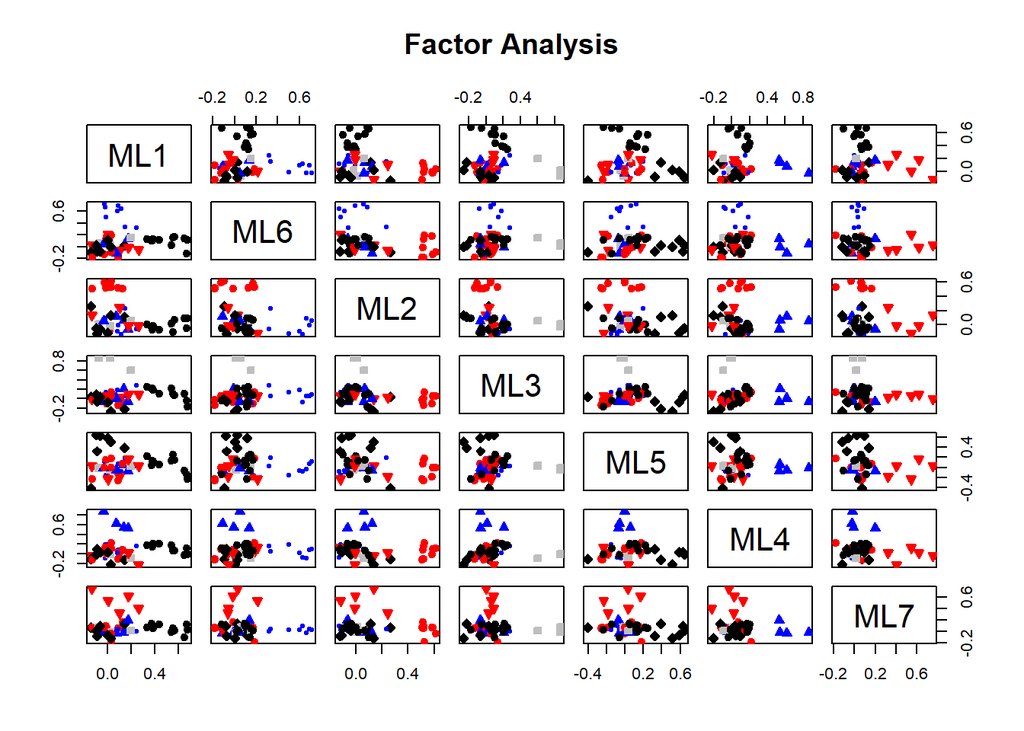

```r
factor.plot(finalmodel, labels=rownames(finalmodel))
```

#To create a diagram of the analysis.

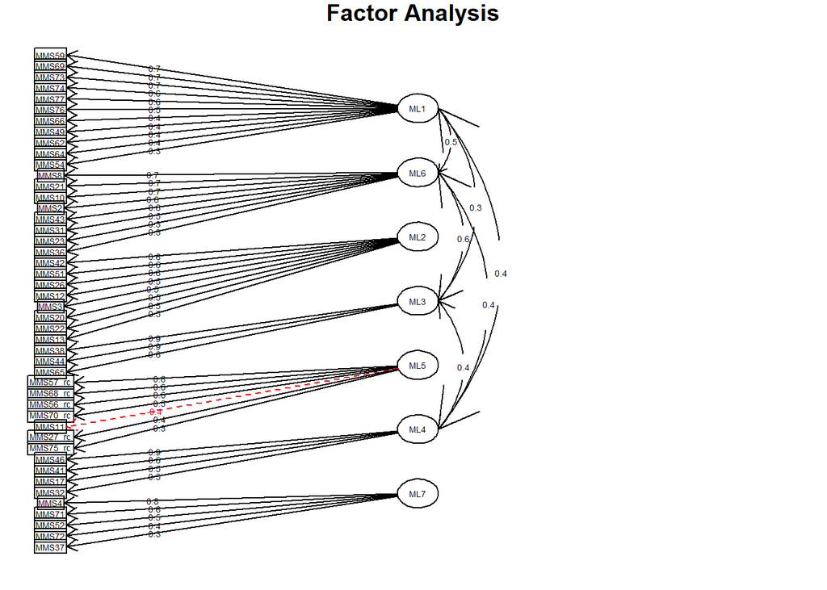

```r
fa.diagram(finalmodel, simple=FALSE)
```

#### To create the seven factor mode.

```r
seven.model='
factone=~MMS49+MMS54+MMS59+MMS62+MMS64+MMS66+MMS69+MMS73+MMS74+MMS76+MMS77
facttwo=~MMS3+MMS12+MMS13+MMS20+MMS22+MMS26+MMS42+MMS51
factthree=~MMS38+MMS44+MMS65
factfour=~MMS17+MMS32+MMS41+MMS46
factorfive=~MMS11+MMS27_rc+MMS56_rc+MMS57_rc+MMS68_rc+MMS70_rc+MMS75_rc
factorsix=~MMS2+MMS8+MMS10+MMS21+MMS23+MMS31+MMS36+MMS43
factorseven=~MMS4+MMS37+MMS52+MMS71+MMS72'
```

#### To create one factor model.

```r
one.model='
factorone=~MMS49+MMS54+MMS59+MMS62+MMS64+MMS66+MMS69+MMS73+MMS74+MMS76+MMS77+MMS3+MMS12+MMS13+MMS20+MMS22+MMS26+MMS42+MMS51+MMS38+MMS44+MMS65+MMS17+MMS32+MMS41+MMS46+MMS11+MMS27_rc+MMS56_rc+MMS57_rc+MMS68_rc+MMS70_rc+MMS75_rc+MMS2+MMS8+MMS10+MMS21+MMS23+MMS31+MMS36+MMS43+MMS4+MMS37+MMS52+MMS71+MMS72'
```

#### run the models.

```r
seven.fit=cfa(seven.model, data=noout)
one.fit=cfa(one.model, data=noout)
```

#### to create path models.

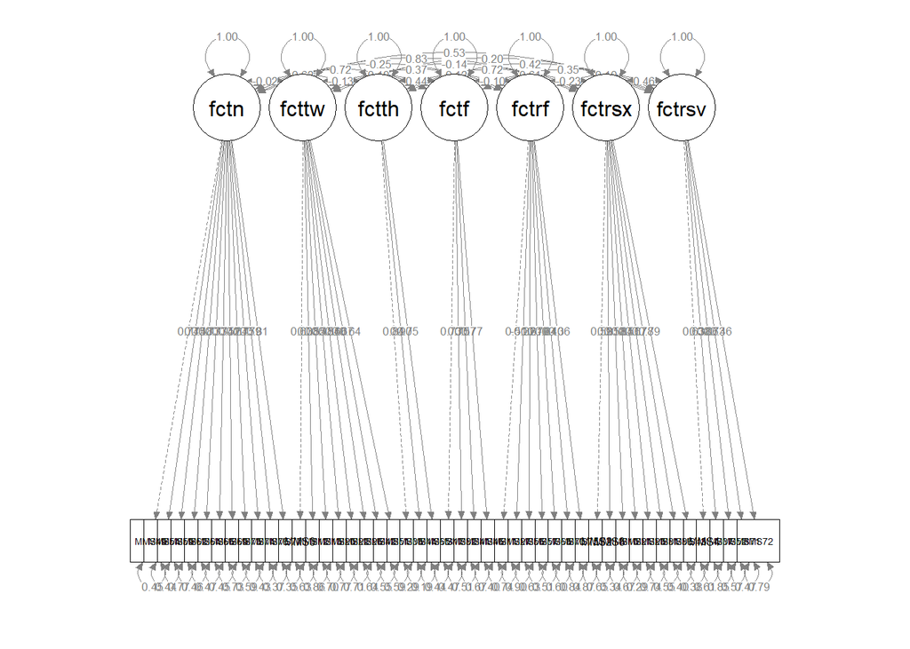

```r
semPaths(seven.fit, whatLabels="std",layout="tree")
```

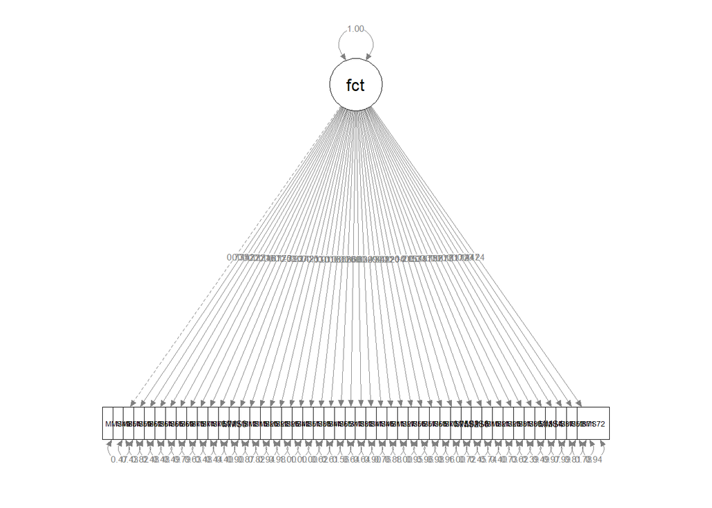

```r
semPaths(one.fit, whatLabels="std",layout="tree")
```

###To check for heywood cases in the 7 factor model. ####to obtain summary statistics for the 7 factor model.

```r
summary(seven.fit, standardized=TRUE, rsquare=TRUE)
```

```
## lavaan (0.5-23.1097) converged normally after  74 iterations
##
##   Number of observations                           237
##
##   Estimator                                         ML
##   Minimum Function Test Statistic             1989.022
##   Degrees of freedom                               968
##   P-value (Chi-square)                           0.000
##
## Parameter Estimates:
##
##   Information                                 Expected
##   Standard Errors                             Standard
##
## Latent Variables:
##                    Estimate  Std.Err  z-value  P(>|z|)   Std.lv  Std.all
##   factone =~
##     MMS49             1.000                               1.373    0.743
##     MMS54             0.985    0.084   11.759    0.000    1.352    0.751
##     MMS59             0.637    0.087    7.288    0.000    0.875    0.479
##     MMS62             0.951    0.083   11.464    0.000    1.306    0.734
##     MMS64             0.913    0.080   11.403    0.000    1.253    0.730
##     MMS66             0.866    0.075   11.544    0.000    1.189    0.738
##     MMS69             0.653    0.082    7.971    0.000    0.896    0.522
##     MMS73             0.873    0.089    9.849    0.000    1.199    0.638
##     MMS74             0.916    0.078   11.783    0.000    1.257    0.752
##     MMS76             1.008    0.081   12.460    0.000    1.384    0.791
##     MMS77             0.948    0.074   12.743    0.000    1.301    0.807
##   facttwo =~
##     MMS3              1.000                               0.785    0.605
##     MMS12             0.740    0.151    4.913    0.000    0.581    0.378
##     MMS13             0.828    0.124    6.675    0.000    0.650    0.547
##     MMS20             0.830    0.138    5.997    0.000    0.651    0.478
##     MMS22             1.049    0.159    6.604    0.000    0.823    0.540
##     MMS26             1.104    0.154    7.147    0.000    0.866    0.600
##     MMS42             1.150    0.149    7.698    0.000    0.903    0.669
##     MMS51             1.117    0.149    7.508    0.000    0.877    0.644
##   factthree =~
##     MMS38             1.000                               1.361    0.841
##     MMS44             1.163    0.072   16.050    0.000    1.583    0.903
```

[output cut: 149 more lines]

```
##     MMS70_rc          0.159
##     MMS75_rc          0.131
##     MMS2              0.351
##     MMS8              0.660
##     MMS10             0.334
##     MMS21             0.712
##     MMS23             0.258
##     MMS31             0.452
##     MMS36             0.604
##     MMS43             0.620
##     MMS4              0.393
##     MMS37             0.146
##     MMS52             0.435
##     MMS71             0.529
##     MMS72             0.214
```

#### All of our error variances are positive and none of our R squared values are over 1 (i.e., we do not have Heywood cases) therefore we procede with CFA.

#### To look for proiblems in fit using a residual correlation table.

```r
correl2 = residuals(seven.fit, type="cor")
correl2
```

```
## $type
## [1] "cor.bollen"
##
## $cor
##          MMS49  MMS54  MMS59  MMS62  MMS64  MMS66  MMS69  MMS73  MMS74
## MMS49     0.000
## MMS54     0.007  0.000
## MMS59    -0.034 -0.042  0.000
## MMS62     0.000 -0.012 -0.075  0.000
## MMS64     0.012 -0.038 -0.046  0.108  0.000
## MMS66    -0.019 -0.057 -0.023  0.068  0.071  0.000
## MMS69    -0.003 -0.096  0.243 -0.017  0.015  0.017  0.000
## MMS73    -0.009 -0.016  0.329 -0.090 -0.036 -0.043  0.100  0.000
## MMS74    -0.010 -0.016  0.059 -0.071 -0.059 -0.054  0.087  0.100  0.000
## MMS76    -0.001  0.021  0.002 -0.018 -0.014  0.030 -0.030 -0.015  0.011
## MMS77    -0.022  0.035 -0.029  0.001 -0.058 -0.015 -0.004  0.000  0.049
## MMS3     -0.218 -0.253  0.077 -0.163 -0.160 -0.135  0.049 -0.075 -0.125
## MMS12     0.335  0.299  0.138  0.220  0.272  0.203  0.120  0.243  0.307
## MMS13    -0.300 -0.334 -0.001 -0.322 -0.297 -0.268 -0.070 -0.138 -0.273
## MMS20     0.167  0.248  0.175  0.135  0.182  0.188  0.085  0.210  0.177
## MMS22     0.111  0.138  0.215  0.067  0.074  0.144  0.170  0.148  0.158
## MMS26    -0.010 -0.073  0.205 -0.028  0.017  0.006  0.049  0.097  0.062
## MMS42     0.006  0.031  0.123  0.033  0.038 -0.010  0.050  0.100  0.048
## MMS51     0.075 -0.046  0.054 -0.015  0.057 -0.002  0.008  0.023  0.032
## MMS38     0.010  0.109 -0.192  0.065  0.053 -0.007 -0.115 -0.008 -0.067
## MMS44     0.021  0.053 -0.208 -0.008  0.026 -0.057 -0.177 -0.085 -0.067
## MMS65     0.084  0.118 -0.024  0.178  0.139  0.077  0.029  0.124  0.126
## MMS17     0.086  0.089 -0.042  0.043  0.052  0.023  0.068  0.009  0.019
## MMS32     0.092  0.052  0.087  0.093  0.127  0.132  0.133  0.017  0.029
## MMS41    -0.021  0.000  0.030 -0.122 -0.121 -0.072  0.054 -0.043 -0.016
## MMS46    -0.040 -0.039 -0.069 -0.053 -0.026 -0.029 -0.073 -0.081 -0.052
## MMS11    -0.146 -0.220  0.082 -0.202 -0.147 -0.114 -0.026 -0.068 -0.145
## MMS27_rc  0.044  0.070  0.028 -0.016 -0.046  0.031 -0.003  0.012  0.077
## MMS56_rc  0.043  0.130 -0.187  0.080  0.036  0.051 -0.147 -0.035  0.060
## MMS57_rc  0.065  0.030 -0.235  0.022 -0.039 -0.015 -0.204 -0.041 -0.009
## MMS68_rc -0.032  0.118 -0.165  0.032 -0.079 -0.045 -0.206 -0.056  0.013
## MMS70_rc -0.182 -0.219 -0.205 -0.201 -0.167 -0.202 -0.185 -0.219 -0.136
## MMS75_rc -0.096 -0.054 -0.155 -0.123 -0.175 -0.178 -0.103 -0.121 -0.110
## MMS2      0.005 -0.041  0.029 -0.016  0.003 -0.012 -0.006  0.038 -0.021
## MMS8     -0.010  0.074 -0.116 -0.027 -0.047 -0.037 -0.141 -0.032  0.038
```

[output cut: 245 more lines]

```
## MMS72     0.000
##
## $mean
##    MMS49    MMS54    MMS59    MMS62    MMS64    MMS66    MMS69    MMS73
##        0        0        0        0        0        0        0        0
##    MMS74    MMS76    MMS77     MMS3    MMS12    MMS13    MMS20    MMS22
##        0        0        0        0        0        0        0        0
##    MMS26    MMS42    MMS51    MMS38    MMS44    MMS65    MMS17    MMS32
##        0        0        0        0        0        0        0        0
##    MMS41    MMS46    MMS11 MMS27_rc MMS56_rc MMS57_rc MMS68_rc MMS70_rc
##        0        0        0        0        0        0        0        0
## MMS75_rc     MMS2     MMS8    MMS10    MMS21    MMS23    MMS31    MMS36
##        0        0        0        0        0        0        0        0
##    MMS43     MMS4    MMS37    MMS52    MMS71    MMS72
##        0        0        0        0        0        0
```

#### To view correlation table.

```r
View(correl2$cor)
zcorrel2 = residuals(seven.fit, type="standardized")
View(zcorrel2$cov)
modindices(seven.fit, sort. =TRUE, minimum.value=3.84)
```

```
##              lhs op      rhs     mi    epc sepc.lv sepc.all sepc.nox
## 490        MMS59 ~~    MMS73 60.390  1.212   1.212    0.353    0.353
## 123      factone =~    MMS13 57.027 -0.388  -0.533   -0.449   -0.449
## 331    factorsix =~    MMS13 46.979 -0.484  -0.493   -0.416   -0.416
## 250     factfour =~    MMS13 45.121 -0.425  -0.513   -0.432   -0.432
## 330    factorsix =~    MMS12 43.622  0.644   0.656    0.427    0.427
## 249     factfour =~    MMS12 43.202  0.574   0.694    0.452    0.452
## 122      factone =~    MMS12 37.274  0.434   0.595    0.388    0.388
## 222    factthree =~ MMS70_rc 35.389 -0.481  -0.655   -0.390   -0.390
## 329    factorsix =~     MMS3 35.058 -0.444  -0.453   -0.349   -0.349
## 248     factfour =~     MMS3 28.901 -0.361  -0.437   -0.337   -0.337
## 206    factthree =~    MMS12 28.443  0.394   0.536    0.349    0.349
## 290   factorfive =~     MMS3 27.745  0.597   0.491    0.378    0.378
## 205    factthree =~     MMS3 27.221 -0.296  -0.403   -0.311   -0.311
## 349    factorsix =~ MMS70_rc 26.695 -0.565  -0.576   -0.343   -0.343
```

[output cut: 250 more lines]

```r
summary(one.fit,standardized=TRUE,rsquare=TRUE)
```

```
## lavaan (0.5-23.1097) converged normally after  36 iterations
##
##   Number of observations                           237
##
##   Estimator                                         ML
##   Minimum Function Test Statistic             3038.793
##   Degrees of freedom                               989
##   P-value (Chi-square)                           0.000
##
## Parameter Estimates:
##
##   Information                                 Expected
##   Standard Errors                             Standard
##
## Latent Variables:
##                    Estimate  Std.Err  z-value  P(>|z|)   Std.lv  Std.all
##   factorone =~
##     MMS49             1.000                               1.350    0.730
##     MMS54             1.003    0.086   11.715    0.000    1.354    0.752
##     MMS59             0.568    0.089    6.398    0.000    0.767    0.420
##     MMS62             0.951    0.085   11.208    0.000    1.284    0.721
##     MMS64             0.914    0.082   11.162    0.000    1.233    0.718
##     MMS66             0.850    0.077   11.057    0.000    1.147    0.712
##     MMS69             0.587    0.083    7.041    0.000    0.792    0.462
##     MMS73             0.843    0.090    9.319    0.000    1.138    0.605
##     MMS74             0.888    0.080   11.149    0.000    1.199    0.718
##     MMS76             0.968    0.083   11.628    0.000    1.306    0.747
##     MMS77             0.926    0.076   12.109    0.000    1.250    0.775
##     MMS3             -0.306    0.063   -4.831    0.000   -0.414   -0.319
##     MMS12             0.417    0.075    5.561    0.000    0.563    0.366
##     MMS13            -0.369    0.058   -6.383    0.000   -0.498   -0.419
##     MMS20             0.252    0.067    3.779    0.000    0.340    0.250
##     MMS22             0.149    0.075    1.982    0.047    0.200    0.131
##     MMS26            -0.015    0.071   -0.214    0.830   -0.021   -0.014
##     MMS42             0.005    0.066    0.077    0.939    0.007    0.005
##     MMS51            -0.034    0.067   -0.509    0.611   -0.046   -0.034
##     MMS38             0.737    0.078    9.463    0.000    0.994    0.614
##     MMS44             0.808    0.084    9.578    0.000    1.090    0.621
##     MMS65             0.781    0.077   10.197    0.000    1.055    0.660
##     MMS17             0.736    0.080    9.214    0.000    0.994    0.599
```

[output cut: 107 more lines]

```
##     MMS70_rc          0.043
##     MMS75_rc          0.003
##     MMS2              0.284
##     MMS8              0.551
##     MMS10             0.260
##     MMS21             0.604
##     MMS23             0.266
##     MMS31             0.375
##     MMS36             0.607
##     MMS43             0.509
##     MMS4              0.030
##     MMS37             0.014
##     MMS52             0.193
##     MMS71             0.221
##     MMS72             0.056
```

```r
fitMeasures(seven.fit)
```

```
##                npar                fmin               chisq
##             113.000               4.196            1989.022
##                  df              pvalue      baseline.chisq
##             968.000               0.000            6100.710
##         baseline.df     baseline.pvalue                 cfi
##            1035.000               0.000               0.798
##                 tli                nnfi                 rfi
##               0.784               0.784               0.651
##                 nfi                pnfi                 ifi
##               0.674               0.630               0.801
##                 rni                logl   unrestricted.logl
##               0.798          -18745.461          -17750.950
##                 aic                 bic              ntotal
##           37716.921           38108.812             237.000
##                bic2               rmsea      rmsea.ci.lower
##           37750.642               0.067               0.063
##      rmsea.ci.upper        rmsea.pvalue                 rmr
##               0.071               0.000               0.288
##          rmr_nomean                srmr        srmr_bentler
##               0.288               0.112               0.112
## srmr_bentler_nomean         srmr_bollen  srmr_bollen_nomean
##               0.112               0.112               0.112
##          srmr_mplus   srmr_mplus_nomean               cn_05
##               0.112               0.112             125.098
##               cn_01                 gfi                agfi
##             128.887               0.719               0.686
##                pgfi                 mfi                ecvi
##               0.644               0.116               9.346
```